# WildPigABM Documentation and Motivation

Jason Holderieath

2017-06-24

# 1 Introduction

This vignette is a companion document to my dissertation essay *Pigs on the wrong side of the fence. An agent-based approach to evaluating the communication of marginal values.* This document contains much of the justification not needed for the story and code to show exactly how the functions work. The vignette is organized by major topic. The Overview, Design, Concepts, and Details section details the relevant features for other agent-based modelers. The subsequent sections document functions and ideas. There is substantially more capability in the model than is on display in the essay and this is apparent upon examination of the functions. The document is designed to fully explain everything about a section within each section. As such, there is substantial overlap between sections. ```

## 1.1 License

Use of the software implies acceptance of the license.

```r
cat(readLines('~/GitHub/Version 2/LICENSE'), sep = '\n')
```

[output not shown]

[output cut: 146 more lines]

```
      identification within third-party archives.

   Copyright 2016 Jason Holderieath

   Licensed under the Apache License, Version 2.0 (the "License");
   you may not use this file except in compliance with the License.
   You may obtain a copy of the License at

       http://www.apache.org/licenses/LICENSE-2.0

   Unless required by applicable law or agreed to in writing, software
   distributed under the License is distributed on an "AS IS" BASIS,
   WITHOUT WARRANTIES OR CONDITIONS OF ANY KIND, either express or implied.
   See the License for the specific language governing permissions and
   limitations under the License.
```

## 1.2 Instructions for use:

1.0 [Download `NetLogo` Version 5.3.1](https://ccl.northwestern.edu/netlogo/download.shtml) `WildPigABM` has not been tested with Version 6.0.1

2.0 [Download Source Files](https://github.com/jholderieath/website/raw/master/WildPigABM_0.2.9.tar.gz)

3.0 If your installation is exactly like mine, you can simply install the r package. The `NetLogo` model will be automatically placed in your `R` package library (i.e. `~\R\win-library\3.3\WildPigABM\data`). The `doOne` will know where to find the `NetLogo` model.

```r
 install.packages("~/WildPigABM_0.2.9.tar.gz", repos = NULL, type = "source")
```

3.1 It is quite likely you will need to modify the `doOne` function to update your generic output directory (`dirc`) and `NetLogo` application path (`nl.path`) must be updated. You may also wish to change other parts of the model. If that is the case, unzip the `tar.gz` file and modify. If you would like to collaborate please contact me through the site.

### 1.2.1 Use of The source files

If you chose option 3.1, extract `/WildPigABM_0.2.9.tar.gz`. The `/data` folder contains the `NetLogo` model. This model contains most of the functions that relate to the physical world. The `/doc` folder contains the documentation for the version of `RNetLogo` I was working with and documentation for a subset and replace operation that is not used in this version, but could be useful. The `/R` folder contains definitions of all `/R` functions. `/Test` contains scripts for testing this and previous versions. `/vignettes` contains the documentation. Please evaluate these files. If you decide that you would like to collaborate, contact me to *request* (I reserve the right to not grant access to *anyone*.) invitation as a collaborator on a private GitHub repository. Depending on the nature of your project, a version or a fork may be used to give you a private version to develop.

# 2 Documentation

## 2.1 Baseline Parameters

Baseline Variable Levels

|  | Baseline Value |
| --- | --- |
| allowableOverCap | 10 |
| boarTerritoryDecay | 1 |
| brange | 5 |
| competingWildlife | FALSE |
| cont | FALSE |
| dam_Corn | 0.02365 |
| dam_CRP | 0 |
| dam_soy | 0.01715 |
| defaultLitter | 0.8 |
| dirc | C:/Users/zejas/Documents/GitHub/Version 2/WildPigABM/inst/examples/output |
| discount | 0.05 |
| effect_comm | 0.9 |
| effect_fee | 0.8 |
| effect_free | 0.65 |
| effect_govt | 0.9 |
| EGM_offFarm | 100 |
| generic_removal_price | 35 |
| gov_budget | 1e+05 |
| govLuck | 0.9 |
| govRemovalPrice | 65 |
| Govt_ON | TRUE |
| init_hh | 45 |
| init_pigs | 100 |
| map_height | 49 |
| map_width | 49 |
| max_cycles | 10 |
| max_pigs | 1440 |
| maxSounderN | 100 |
| mergeAccelerator | 0.25 |
| mergedistance | 100 |
| minPigsFee | 10 |
| minSounderN | 4 |
| multiYearLand | TRUE |
| nl.path | C:/Program Files/NetLogo 5.3.1/app |
| num_choice | 12 |
| P_corn | 3.71 |
| P_CRP | 100 |
| P_feePaying | 300 |
| P_soy | 9.15 |
| patchSize | 10 |
| pig_range | 10 |
| sdMult | 0 |
| sexRatio | 0.25 |
| SounderterritoryDecay | 1 |
| splitAccelerator | 0.25 |
| srange | 5 |
| stochastic | FALSE |
| swf | 1 |
| t_corn | 0.5 |
| t_CRP | 2.22e-16 |
| t_FEEPAYING | 1 |
| t_offfarm | 1 |
| t_PAIDREMOVAL | 2.22e-16 |
| t_soy | 0.5 |
| t_UNPAIDNOT | 2.22e-16 |
| t_UNPAIDPRES | 1 |
| varCost_corn | 3740 |
| varCost_Fee | 100 |
| varCost_free | 2.22e-16 |
| varCost_offFarm | 2.22e-16 |
| varCost_Paid | 65 |
| varCost_soy | 2360 |
| verboseR | TRUE |
| verCost_CRP | 2.22e-16 |
| wealth | 5e+05 |
| Yield_corn | 1350 |
| Yield_soy | 450 |
| model.path | system.file(“data/FromR_1.0.nlogo”,package = “WildPigABM”) |
| seed | 28128868 |
| init_sounder | 5 |

## 2.2 Overview, Design Concepts, and Details

### 2.2.1 Purpose

The overarching purpose of the model is to provide a tool for analysis of feral swine management issues where interactions between people, pigs, and politicians could matter. In the “Core Paper” simulation we are specifically looking at the impacts of expectations forming in decision-making.

### 2.2.2 Entities, state variables, and scales

This model has a large number of moving parts. The agents are landowners and three types of feral swine. Landownership is defined prior to the simulation. Land is of varying quality. Landowners are characterized by their wealth and activities. Feral swine are characterized by their location, age, sex, and their status as living. Temporal scales are a multi-year simulation with explicit annual time steps. Spatial scales are They exist in a space a little over 6 miles long by 6 miles wide, made up of 2401 ten acre patches.

### 2.2.3 Process overview and scheduling

1. Initialize.
2. Landowners (or social planners) plan the year.
- Landowners assess their resource base.
- Use LP model to solve for their activities.
- Observer records most of the optimization data pieces.
3. Pig operations are conducted.
- Caginess is updated.
- They reproduce.
- Sounders split and merge.
- Assess their surroundings in preparation for movement.
- Move to a more desired location.
4. Removal operations are conducted.
- Census of feral swine.
- Calculation of patch intensity of effort.
- Calculation of inividual swine probability of removal.
- Death for those swine above the threshold.
5. Landowner year-end operations are conducted.
- Assess damage inflicted by remaining feral swine.
- Calculate updated net income from operations and off-farm work.
- Update wealth of the household.
6. Year-end inventories, clean-up, and save operations are conducted.
7. Simulation-end save operations are completed.

### 2.2.4 Design concepts

Design concepts have been summarized in the table below.

| Design concepts applied to landowners |  |
| --- | --- |
| Basic Principles | Landowners are complex. |
| Emergence | Management will depend on outlook |
| Adaptation | Regardless of the type of the manager, each year landowners reassess their situation. |
| Objectives | Gross margin maximization over a specified period of time |
| Learning | No explicit learning is modeled. |
| Prediction | Landowners are forward-looking into at least the current period, with old information. |
| Sensing | Landowners are aware of feral swine presence on their property. |
| Interaction | Landowners interact with feral swine by removing them. Landowners interact with each other indirectly by pursuing goals. |
| Stochasticity | Landowners are placed by stochastic processes. |
| Collectives | Only in the social planner simulations, in that case the collective planning process is imposed. |
| Observation | Wealth, income, decision-making criteria, and plans are retained. |

| Design concepts applied to government |  |
| --- | --- |
| Basic Principles | Government is effectively absent for this set of simulations. |
| Emergence | The machinery is in place for future experiments. |
| Adaptation |  |
| Objectives |  |
| Learning |  |
| Prediction |  |
| Sensing |  |
| Interaction |  |
| Stochasticity |  |
| Collectives |  |
| Observation |  |

| Design concepts applied to feral swine |  |
| --- | --- |
| Basic Principles | Feral swine seek to live and reproduce. |
| Emergence | Movement will be sensitive to group dynamics. |
| Adaptation | Feral swine move in space away from crowding and removal pressure. |
| Objectives | Survival, reproduction. |
| Learning | No explicit learning is modeled. |
| Prediction | Feral swine are not forward looking. |
| Sensing | Feral swine are able to sense removal pressure and crowding. |
| Interaction | Feral swine interact with the other agents by moving away from removal pressure, and by causing damage. |
| Stochasticity | Initial placement is due to a stochastic process. |
| Collectives | Females are part of groups known as sounders. |
| Observation | A census of feral swine is kept each time period. |

### 2.2.5 Initialization

Initialization is a fairly complex operation. In order:

- Inside the `doOne` function:
- The seed is specified. (If we had been looking to simulate across a number of different worlds we would have specified a stream of random number seeds in step 2).
- Static variables are defined.
- The `masterSchedule` function is called with the static variables, variables from the grid, and the RNG seed.
- Inside the `masterSchedule` function:
- Matrices and values are calculated for later use (e.g. a null and unit matrix).
- The clock is started for timing simulations.
- NetLogo is loaded into the `R` session using `RNetLogo::NLStart()` and the `NetLogo` portion of the model is loaded using `RNetLogo::NLLoadModel()`.
- If `gui = TRUE` the user is asked to press `[enter]` to continue. This gives the user an opportunity to troubleshoot the loading process.
- The seed is passed to `NetLogo`.
- Initial patch variables are created and passed to `NetLogo`
  - A uniform distribution is used to create initial values for each patch by generating a value in an array. The variables generated are `quality`, four effectiveness variables used in other simulations, and a memory variable defining the tendency of feral swine on a given patch to remember previous control efforts. `Patch_id` is assigned, and control effort in the period prior to the simulation is set to zero.
  - Those variables are passed to `NetLogo` using the `NL_pushToMap` function defined in “Processing Functions.”
  - Variable costs, prices, time requirements, and baseline yields are assigned to each patch (non-stochastically) and passed using the `RNetLogo::NLSetPatches` function.
- A dataframe of variables used to define global variables is defined and sent to `NetLogo` using the `initialGlobalVariable` function.
- The `NetLogo` setup function is called.
  - A clean slate is created, along with empty lists for tracking, and default shapes set.
  - `setup-patches`
    - Max pigs per patch defined.
    - Set as ownerless and without pigs, previous removal effort, or income.
    - Yield is adjusted for quality of the land.
  - `setup-seededHH`
    - Randomly place `init_hh` number of households.
  - `setup-hh`
    - Farmstead is built, id number assigned.
  - `setup-landgrab`
    - `init_hh` number of patches with an owner claim an unclaimed neighbor. The process repeats until all patches are claimed.
  - `setup-roads`
    - Roads are created as a visual aid. They serve no other purpose.
  - `setup-boars`
    - A number of boars are created in a random location with age = 0.
  - `setup-sows`
    - A number of sows are created in a random location with age = 0.
    - Sows are then randomly assigned to a group (sounder).
- Result space matrices and lists are created.

### 2.2.6 Input data

No data files are read into the simulation as described by Railsback and Grimm (2011).

### 2.2.7 Submodels

Submodels are described in detail in the following sections of the vignette.

## 2.3 Core Paper Optimization Framework

### 2.3.1 Release Notes

The optimization process included in versions 0.2.9 and later is the most expansible yet. More emphaisis has been placed on modularity. This modularity is seen in the `masterSchedule` designation of type of price and landowner allowing mixed assignments, removal cost, damage functions, and OCPM functions can all be easily changed. As improvements are made in newer versions this vision of modularity will continue. Future versions will move more and more to a software package that a novice can use. Much of the effort that has gone into this package has been spent on landowner optimization.

Please contact me if you would like to collaborate. The following issues are currently outstanding in a private repository.

- [Add support for commercial solver packages](https://github.com/jholderieath/Version-2/issues/7) In particular, IBM’s CPLEX, Gurobi, GAMS, and Mosek solvers all have strengths that could be useful.
- [Add GPU Solver Option](https://github.com/jholderieath/Version-2/issues/6) A GPU solver option would speed up computation greatly - even if it does not speed up an individual optimization, it would allow developers to move many of the calculations off of the CPU and to the GPU speeding up those operations.
- [Add support for Non-linear Optimization and Dynamic Programming](https://github.com/jholderieath/Version-2/issues/5) Improving granularity in the decision-maker’s choice space could improve the model. It could slow it down though.

### 2.3.2 The land-manager’s decision

Each type of decision maker uses the same pieces of information to make his decision. Landowners are aware of the presence of feral swine ($pigTerritoryStrength$) and are able to assess associated likely damage, as well as their expected impact for no removal effort ($pop\_if\_none$), light removal effort of attempting to remove 25% of the population ($pop\_if\_light$), and heavy removal effort of attempting to remove 90% of the population ($pop\_if\_heavy$).

### 2.3.3 Implementation

Implementation between each type of decision is fairly similar. From the `masterSchedule`, `if` statements choose the appropriate optimization function.

```r
if(RemovalPriceMethod=="random"){
  a<-c("marginal","minus","linear")
  removalPrFnVec <- sample(a, init_hh, replace=TRUE)
}
if(RemovalPriceMethod=="linear"){
  removalPrFnVec <- rep_len("linear",length.out = init_hh)
}
if(RemovalPriceMethod=="marginal"){
  removalPrFnVec <- rep_len("marginal",length.out = init_hh)
}
if(RemovalPriceMethod=="minus"){
  removalPrFnVec <- rep_len("minus",length.out = init_hh)
}
if(UserCostMethod=="random"){
  a<-c("myopic","minus","linear")
  userCostFnVec <- sample(a, init_hh, replace=TRUE)
}
if(UserCostMethod=="myopic"){
  userCostFnVec <- rep_len("myopic",length.out = init_hh)
}
if(UserCostMethod=="minus"){
  userCostFnVec <- rep_len("minus",length.out = init_hh)
}
if(UserCostMethod=="linear"){
  userCostFnVec <- rep_len("linear",length.out = init_hh)
}
```

Then inside the time loop.

```r
    plan[t] <- RevisedDynamicISH(verboseR, t, now,today,init_hh,
                                             P_corn,P_soy,P_CRP,
                                             varCost_corn, varCost_soy,verCost_CRP,
                                             removalPrFnVec,userCostFnVec,typeDecision,
                                              bounty,
                                             ...)
```

```r
#' @rdname WildPigABM
#' @export
removalPrice <- function(x){
  35.404 + (1464)/(1 + (x/3.299004)^1.843566)
}

#' @rdname WildPigABM
#' @export
pctDamFunc <- function(x){ 0.9 + (-0.899)/(1 + (x/14.21)^5)}

#' @rdname WildPigABM
#' @export
incrRemovalPrice <- function(x,y,...){
sum(removalPrice(x:y))
}

#' @rdname WildPigABM
#' @export
minusUserCost <- function(pop_if_none,pop_if,...){
  x <- pop_if_none
  y <- pop_if
  z = x-y
  (userCostf(y)-userCostf(x))*z
}


#' @rdname WildPigABM
#' @export
estGM <- function(pop_if_none, pop_if_light, pop_if_heavy ,
                  dam_corn,dam_soy,dam_crp,
                  adjYieldCorn, adjYieldSoy,
                  P_corn, p_soy, p_crp,
                  varCost_corn,varCost_soy,varCost_crp,
                  dFnForm,Removal_Price,User_Cost,bounty,...){
  P_crp=P_CRP
  varCost_crp=verCost_CRP
  adjYieldCRP=10
# linDam <- ifelse(dFnForm=="linear",1,0)
# SigDam <- ifelse(dFnForm=="sigmoidal",1,0)
linear <- ifelse(Removal_Price=="linear",1,0)
marginal <- ifelse(Removal_Price=="marginal",1,0)
minus <- ifelse(Removal_Price=="minus",1,0)
ucminus <- ifelse(User_Cost=="minus",1,0)
ucmyopic <- 0
uclinear <- ifelse(User_Cost=="linear",1,0)


K = list("Corn","Soy","CRP")
KK = list("none","light","heavy")
for (k in 1:length(K)){
  for (kk in 1:length(KK)){
    p<-get(paste0("P_",tolower(K[[k]])))
    y<-get(paste0("adjYield",K[[k]]))
    d<-get(paste0("pop_if_",KK[[kk]]))
    vc<-get(paste0("varCost_",tolower(K[[k]])))

    gm <- p*(y-y*pctDamFunc(d))-vc-   #Net Income
      linear*(removalPrice(d)*(pop_if_none-d)) - # linear removal pricing
      marginal*(incrRemovalPrice(pop_if_none,d))- # removal price evaluated at each animal removed
      minus*((removalPrice(d)-removalPrice(pop_if_none))*(pop_if_none-d))+ #removal price is difference of evaluated price times removed animals
      ucminus*(minusUserCost(pop_if_none,d))-
      ucmyopic*(d)-
      uclinear*(userCostf(d)*(pop_if_none-d))+
      bounty*(pop_if_none-d)

    nam <- paste0("gm_",tolower(K[[k]]),"_",KK[[kk]])

    assign(nam,gm)
  }
}
return(c(gm_corn_none,
         gm_corn_light,
         gm_corn_heavy,
         gm_soy_none,
         gm_soy_light,
         gm_soy_heavy,
         gm_crp_none,
         gm_crp_light,
         gm_crp_heavy ))
}



#============================================================================
# All of the landowner decision making functions use the same framework.
# The only difference is the forumulation of the objective function.
# The revised dynamicish function realizes this and provides flexibility for
# mixed levels of rationality.

#' @rdname WildPigABM
#' @export
RevisedDynamicISH <- function(verboseR, t, now,today,
                       init_hh,
                       P_corn,P_soy,P_CRP,
                       varCost_corn, varCost_soy,verCost_CRP,
                       removalPrFnVec,userCostFnVec,typeDecision,bounty,
                       ...) {
    ## NL has all it needs
    RNetLogo::NLCommand('dynamic-prep-step1')
    Sys.sleep(2)
    landownersolution <- list()
    #start looping
    for (j in 1:init_hh) {
      hh <- j - 1
      if (verboseR == TRUE) {print(paste("hh=", hh))}
      patchset <- paste("patches with [owner = ",hh,"]")
      dat <- RNetLogo::NLGetPatches(c(
        "pxcor", "pycor",'pop_if_none',
        'pop_if_light',
        'pop_if_heavy',
        'adjYieldCorn',
        'adjYieldSoy',
        "pigTerritoryStrength"),
        patchset)
      Sys.sleep(2)

      pigTerritoryStrength <- as.vector(dat$pigTerritoryStrength)
      pop_if_none <- as.vector(dat$pop_if_none)
      pop_if_light <- as.vector(dat$pop_if_light)
      pop_if_heavy <- as.vector(dat$pop_if_heavy)
      adjYieldCorn <- as.vector(dat$adjYieldCorn)
      adjYieldSoy <- as.vector(dat$adjYieldSoy)

      #========== eval marginal cost at current, and cost at proposed population subtract
      #fun.6
      #usercost
      #f
      #set gross margins

      obj <- estGM(pop_if_none=pop_if_none,
                   pop_if_light=pop_if_light,
                   pop_if_heavy=pop_if_heavy,
                   dam_corn=dam_Corn,
                   dam_soy=dam_soy,
                   dam_crp=dam_CRP,
                   adjYieldCorn=adjYieldCorn,
                   adjYieldSoy=adjYieldSoy,
                   P_corn=P_corn,
                   P_soy=P_soy,
                   P_crp=P_CRP,
                   varCost_corn=varCost_corn,
                   varCost_soy=varCost_soy,
                   varCost_crp=verCost_CRP,
                   dFnForm=NULL,
                   Removal_Price=removalPrFnVec[j],
                   User_Cost=userCostFnVec[j],
                   bounty=bounty)
      pc <- nrow(dat)

      #Build patch use restriction matrix
      #Looks like [I|I...]
      pu  <- cbind(
        diag(pc),
        diag(pc),
        diag(pc),

        diag(pc),
        diag(pc),
        diag(pc),

        diag(pc),
        diag(pc),
        diag(pc))
      #Overkill at this point, previous versions needed to put together many submatrices
      #into a single large matrix
      mat <- rbind(pu)
      #RHS is all 1s
      rhs <- c(rep_len(1,  length.out = pc))
      #all eq. are stated as <=
      dir <- c(rep_len('<=', length.out = pc))
      #all choice variables are continuious
      types <- c(rep_len('C', length.out = pc * 9))

      indd <- c(1:(pc * 9))
      bounds <- list(lower = list(ind=indd,val=c(rep_len(0, length.out = (pc * 9)))),
                     upper = list(ind=indd,val=c(rep_len(1, length.out = (pc * 9))))
      )

      soln <- Rglpk::Rglpk_solve_LP(obj, mat=mat, dir, rhs,
                                    bounds = bounds,
                                    types = types,
                                    max = TRUE,
                                    control =
                                      list("presolve" = TRUE,
                                           "tm_limit" = 120000,
                                           verbose = TRUE,
                                           canonicalize_status = FALSE))
      solution <- soln$solution
      optimum <- soln$optimum
      status <- soln$status
      spaceFrom <- seq(1,pc*8+1,pc)
      spaceTo <- seq(pc,pc*9,pc)
      Sys.sleep(1)

      dat$a_corn_none <- solution[spaceFrom[1]:spaceTo[1]]
      myvars <- c("pxcor", "pycor", "a_corn_none")

      transfer <- dat[myvars]
      RNetLogo::NLSetPatchSet('a_corn_none',transfer)
      Sys.sleep(1)

      dat$a_corn_light <- solution[spaceFrom[1]:spaceTo[1]]
      transfer <- dat[c("pxcor","pycor","a_corn_light")]
      RNetLogo::NLSetPatchSet('a_corn_light',transfer)
      Sys.sleep(1)

      dat$a_corn_heavy <- solution[spaceFrom[2]:spaceTo[2]]
      transfer <- dat[c("pxcor","pycor","a_corn_heavy")]
      RNetLogo::NLSetPatchSet('a_corn_heavy',transfer)
      Sys.sleep(1)

      dat$a_soy_none <- solution[spaceFrom[3]:spaceTo[3]]
      transfer <- dat[c("pxcor","pycor","a_soy_none")]
      RNetLogo::NLSetPatchSet('a_soy_none',transfer)
      Sys.sleep(1)

      dat$a_soy_light <- solution[spaceFrom[4]:spaceTo[4]]
      transfer <- dat[c("pxcor","pycor","a_soy_light")]
      RNetLogo::NLSetPatchSet('a_soy_light',transfer)
      Sys.sleep(1)

      dat$a_soy_heavy <- solution[spaceFrom[5]:spaceTo[5]]
      transfer <- dat[c("pxcor","pycor","a_soy_heavy")]
      RNetLogo::NLSetPatchSet('a_soy_heavy',transfer)
      Sys.sleep(1)

      dat$a_CRP_none <- solution[spaceFrom[6]:spaceTo[6]]
      transfer <- dat[c("pxcor","pycor","a_CRP_none")]
      RNetLogo::NLSetPatchSet('a_CRP_none',transfer)
      Sys.sleep(1)

      dat$a_CRP_light <- solution[spaceFrom[7]:spaceTo[7]]
      transfer <- dat[c("pxcor","pycor","a_CRP_light")]
      RNetLogo::NLSetPatchSet('a_CRP_light',transfer)
      Sys.sleep(1)

      dat$a_CRP_heavy <- solution[spaceFrom[8]:spaceTo[8]]
      transfer <- dat[c("pxcor","pycor","a_CRP_heavy")]
      RNetLogo::NLSetPatchSet('a_CRP_heavy',transfer)
      Sys.sleep(1)



      if (verboseR == TRUE) {print(paste("LU pushed in period", t, "for HH",j))}
      print(dim(list))
      print(dim(solution))
      print(dim(optimum))
      print(dim(status))
      print(dim(obj))
      print(dim(mat))
      print(dim(dir))
      print(dim(rhs))


      landownersolution[j] <- list(solution=solution,
                                   dat=dat,
                                   optimum=optimum,
                                   status=status,
                                   obj=obj,
                                   mat=mat,
                                   dir=dir,
                                   rhs=rhs)
    }
    mainDir <- "C:/Users/zejas/OneDrive - Colostate/DissertationTopics/ABM/Intermediate_output/"
    subDir <- format(today, format="%Y%b%d")
    dirc <- paste(mainDir,subDir,"/",sep = "")
    dir.create(file.path(dirc), showWarnings = FALSE, recursive = FALSE)
    nam <- paste(dirc,"decisionReturn",t,j,"_",typeDecision,".rda", sep = "")
    save(landownersolution,file = nam)
    return(landownersolution)
  }
```

## 2.4 Opportunity Cost of Postponement of Management (OCPM)

A technique needs to be developed to account for costs imposed by an animal surviving into the next planning period. Expectations about prices have been handled a variety of ways (Shi and Irwin 2005; Thijssen 1996), however feral swine are living and reproducing organisms making forming expectations of their impact more nuanced. Feral swine move, reproduce, die, cause damage according to a non-linear function, and are increasingly expensive to remove as the population is driven to zero.

A simple example of this phenomena near to the hearts of spring residents of Northern Colorado, is spring allergies. Many of us suffer from spring allergies, and maintain a tolerable level of inflamation with some over the counter antihistimine. The antihistimine is relatively low cost and maintains adequate control. We could get shots and cure ourselves – that would be very costly in terms of both time and money and the discomfort of recieving injections. If we fail to control our allergies there can be much more severe and costly conditions, such as pnemonia, that can arise. It is also concievable that our willingness to pay for injections is constrained by some factor currently, and in future periods injections may be the optimal form of management.

Like the allergies, feral swine impact producers differently as a function of population. If the population gets out of hand, it can be very damaging and very costly to bring back into an acceptable level of damage. Differing levels of control can be optimal given different circumstances, and an optimal management plan may include letting a given animal live another period. The added level of complexity that feral swine carry is that they reproduce, and progeny will very quickly be inflicting damage. The following paragraphs will explore the necessity, mathematics, and estimation of what we will coin, “Opportunity Cost of Postponement of Management (OCPM)”. We draw inspriation from, but do not necessarily emulate the concept of “user cost” from the natural resources literature relating to extraction of a resource (see Berck and Helfand 2011, ch. 16 & Field (2001), ch. 10). In that literature, the manager is concerned with not over- or under-extracting a resource in order to balance costs (especially opportunity costs) and benefits across time.

If one were to simply find the net present value or discounted sum of future damages (see Moss 2013, ch. 5), the effect of progeny would be missed. If damage was inflicted linearly (such as in Zivin, Hueth, and Zilberman (2000)), we could use a formula for present value of a perpetuity, $PV=\frac{PMT}{r-g}$, where $PV$ is present value, $PMT$ is the annual cash flow inflicted by feral swine, $r$ is the discount rate, and $g$ is the annual population growth rate. However, while the exact functional form is unknown, a linear damage function does not follow the narrative that we hear from producers and does not make logical sense.

A non-linear damage function fits the known behavior of feral swine. First, the damage function must be able to handle populations greater than estimated carrying capacity. In Zivin, Hueth, and Zilberman (2000) the function is based on full damage of 90% being carried out by a population of 15 animals.

> Damage to rangeland, measured as a percentage loss of total revenue, is modeled as a linear function of pig population density (Barrett [16]):
> $$D(N) = cN$$
> Data and information on rangeland damage were collected from a number of studies (Barrett et al. [10], Sterner and Barrett [12], Barrett [17]). Based on this information, and through conversations with Barrett [16], $c$ was set equal to 0.06. This implies that at full carrying capacity (15 pigs/km2), total rangeland damage is 90%. Because there is considerable uncertainty associated with this parameter, we vary this coefficient and examine its impact on steady-state results. (Zivin, Hueth, and Zilberman 2000, 197–98)

Additionaly, a linear reduction in population is almost certainly not optimal from an optimal management perspective. This is what is found here, discussed later in the estimation portion of this discussion, and is typical in these types of problems. A reasonable followup question to this statement is, why not just use a planning technique that will produce optimal management?

We want to abstract away from an optimal management scenario to test differing levels of adherance to expert opinion. For instance, if one were to hire a consultant or ask for assistance from an extension agent about their feral swine problem, they would likely not be presented with a fully optimal management plan that accounts for movement, reproduction, resistance to control measures, the particular damage function of that farm, etc. The producer would be presented with a rule of thumb or may be presented something more complex and then act on it inappropriately. As discussed earlier, one person’s mismanagement or refusal to cooperate will have consequences beyond their property borders. If we can condence the essence of an optimal management plan and then test different implementations of that management plan we can address this communication issue.

### 2.4.1 Presentation of the Mathematics

The central idea behind optimal management of feral swine is that across both time and space producers will choose to apply the input (control) to the point at which the value of its marginal product is just equal to its per-unit market price. The input is control, or a desired remaining population. The value of the output of this input is avoided damage - from this animal and its progeny.

#### 2.4.1.1 Control Costs

As mentioned earlier, the removal of feral swine is increasingly difficult as the population approaches zero. The most extreme statement of this is:

$$\lim_{n\to0} w_{control}(n) \ \to L.$$

There have been successful eradication campaigns, so the price of removal to zero is not infinite. Saunders and Bryant (1988) proposed a removal cost function based on flight time used in an exercise in Australia,

> p = 1 - 1.177exp(0.001375t). With one helicopter we can assume an average of 400 min flying time per day. To remove 95% of the population would have therefore taken the exercise to 7 days (2297 min). Similarly, a 99% reduction would take 9 days (3468 min). (Saunders and Bryant 1988, 78)

Wildlife managers understand the increasing cost of removal, but they also understand the need to communicate average costs. That is, we know that we are currently removing something close to 20-30% of the feral swine in Texas (Carson 2013) and mixed removal actions in Texas cost approximately $65/head (Bodenchuk 2014). If we solve the equation proposed by Saunders and Bryant (1988) for $t$, we find:

$$t = 8000/11 \times ln(-100/177 \times (p-1)) \ for \ p<1.$$

However, what we really need is a pricing mechanism for professional removal that reflects the increasing difficulty of removing as the population reaches zero. A function like the one below reflects the price we currently face with abundant populations and approaches the theoretical price curve proposed by Saunders and Bryant (1988).

$$w_{control}=35.404 + (1464)/(1 + (x)/3.299004)^{1.843566})$$

Plotted, this function retains the shape of Saunders and Bryant (1988) but instead works off of the expected remaining population and calibrates to approximate twenty percent removal at approximately $65/head and removal of the last animal at approximately $1500.

#### 2.4.1.2 Damage

As discussed earlier, there is a maximum level of damage and that when the population changes, damage changes non-linearly. These ideas can be fitted to a sigmoidal curve. A symmetric sigmoidal curve set to be very near zero at a population of zero and to max out at 90% damage at a full population of 30 head in the 2km^2 area.

$$y=0.9 + (-0.899)/(1 + (x/14.21)^5)$$

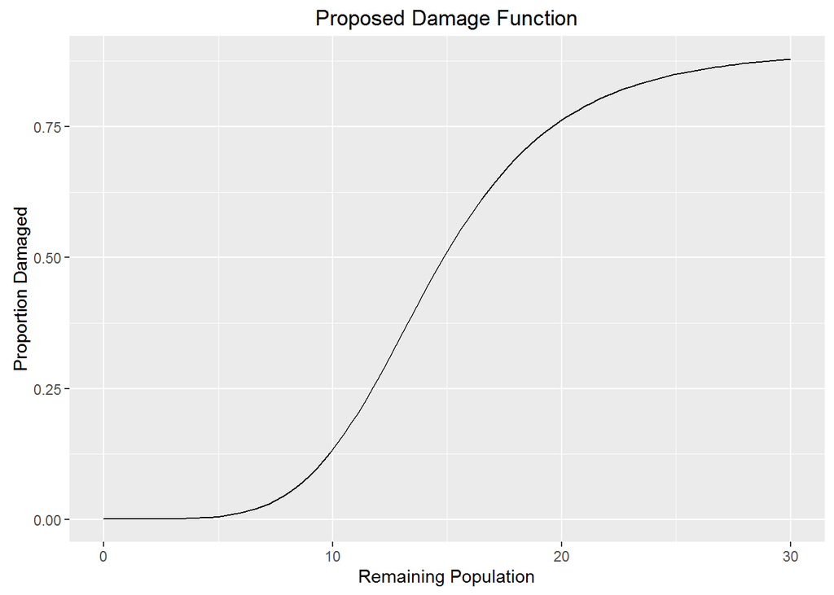

#### 2.4.1.3 Marginal Conditions

Both control and damage are a function of remaining population, rather than control effort. In addition, benefit is an avoided cost. They are two sides of the same coin, however, a subtle shift in interpretation of the marginal conditions is required. First, find the marginal damage for corn and soybeans.

$$\text{differentiate } damage_{corn} = (0.9 - 0.899/(1 + (x/14.21)^5)) \times 1350 \times 3.71 \text{ w.r.t. x}$$

$$damage_{corn}'(x) = (1.30439×10^{10} \times x^4)/(x^5 + 579389)^2$$

$$\text{differentiate } damage_{soy} = (0.9 - 0.899/(1 + (x/14.21)^5)) \times 450 \times 9.15 \text{ w.r.t. x}$$

$$damage_{soy}'(x) = (1.07234×10^{10} \times x^4)/(x^5 + 579389)^2$$

Then the cost of achieving a remaining population. There are more benefits to removal than the single season. We should include future benefits. It is unclear how long a decision-maker will plan, however, a perfect planner would look forward infinitely. The present value of a perpetuity is:

$$PV=PMT/r$$

where $PV$ is present value, $PMT$ is a payment, and $r$ is a dicount rate.

$$damage_{corn, perpetuity}'(x)= (2.60878x10^{11} x^4)/(x^5 + 579389)^2$$

$$damage_{soy, perpetuity}'(x) = (2.14469x10^{11} x^4)/(x^5 + 579389)^2$$

The cost of removal function can be differentiated:

$$removal'(1x) = (24371 \times x^{0.843566})/(x^{1.84357} + 9.02969)^2$$

$$removal'(4x) = (97483.9 \times x^{0.843566})/(x^{1.84357} + 9.02969)^2.$$

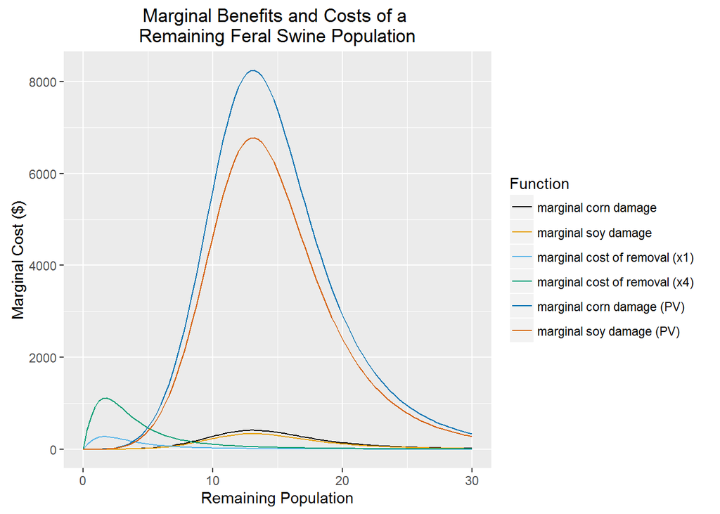

The plotted functions show marginal cost of a remaining population. Again, this graph does not show the demand for or the cost of a given unit of control. It shows the costs and and benefit of a remaining population. Clearly, the myopic planner and a forward looking planner will arrive at different outcomes. Even this much higher function might be an understatement. These marginal present value functions do not consider reproductive capacity of a single animal. The dynamic model presented in the next section will account for the progeny of an animal.

### 2.4.2 Estimation

To estimate the essence of an expert we simplify the problem to dimensions that can be understood on a per animal basis. A non-linear programming (NLP) routine is used to find optimal management of a smaller problem. This optimization routine was implemented in `GAMS`. The cost of an additional animal in future periods is then distilled to a function for use in the agent-based model.

The model philosophy was changed slightly to reflect a move toward (but not completely achieving) optimal management. A single decision-maker maximizes gross margin for a subset of the larger map. The world is reduced to the assumed range of an animal of approximately 2 km^2 (see Schlichting et al. 2016). The 490 acres of this world are managed as one unit, with no movement into or out of the area. This implicitly assumes that everyone will engage in the same actions. The model is estimated for a 75 year planning horizon, sufficiently long to make terminal conditions irrelevant.

The same crop prices, yields, and variable costs are used. Quality is the average for the subset of patches included.

Initial conditions are established, creating a state with an initial population ,as well as no removal, no land use, or damage in the initial period. Initial population, set initial population at a variable level for analysis.

$$initPigs = rP_{n1,t} \ if \ ord_t=1$$

Intitial removal efforts are restricted to the level of the initial number of animals.

$$q_{n1,t} < initPigs if \ ord_t=1$$

To avoid complete removal at initialization, and preventing the harvest of a marginal value of a remaining animal, Initial removal price is set very high.

$$P\_removal_{n1,t}= 10000 \ if \ ord_t=1$$

Population dynmaics are essentially previous population plus growth minus removed equals ending population.

$$rP_{n1,t-1}+(rP_{n1,t-1}\times gamma \times (1-(rP_{n1,t-1} maxD^{-1})))-q_{n1,t}=rP_{n1,t} \ \forall \ t \ if \ ord_t \ne 1$$

Removal is restricted to the number of animals present at the beginning of a time-step.

$$q_{n1,t} \le rP_{n1,t-1} \ \forall \ t \ if \ ord_t \ne 1$$

A symmetric sigmoidal curve set to be very near zero at a population of zero and to max out at 90% damage at a full population of 30 head in the 2km^2 area.

$$dam_{n1,t}=0.9 + (-0.899)/(1 + (rP_{n1,t}/14.21)^5)$$

Price of removal is increasing at an increasing rate as the remaining population approaches zero and is an implementation of the removal function developed above.

$$P\_removal_{n1,t} = 35.404 + (1464)/(1 + (rP_{n1,t}/3.299004)^{1.843566})$$

Patches are restricted to a single use in a given season.

$$\sum_{k} ( use_{k,n1,t} ) < 1 \ \forall \ t \ if \ ord_t \ne 1$$

Finally, the objective function to be maximized is a total discounted benefits ($z$) function.

$$z = \sum_{k,n1,t} ( \\
(P_{k} \times Yield_{k} \times Quality_{n1} - VC_{k}) \times use_{k,n1,t} - \\
(P_{k} \times Yield_{k} \times Quality_{n1} \times dam_{n1,t}) \times use_{k,n1,t} - \\
(P\_removal_{n1,t} \times q_{n1,t}) \\
)\times (1+r)^{-t}$$

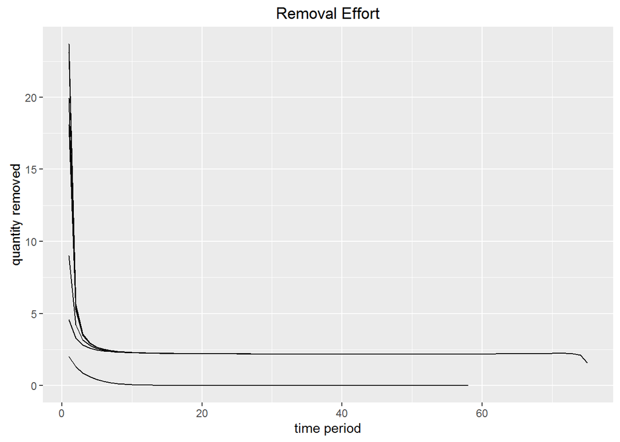

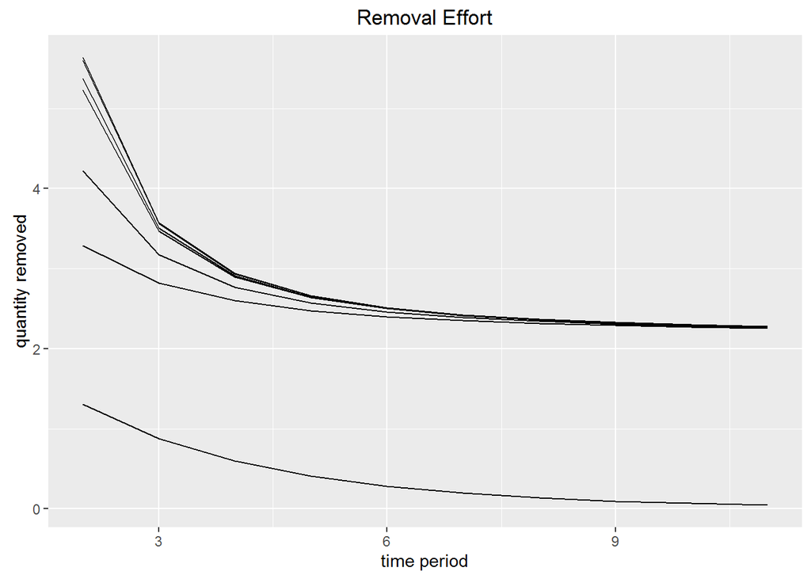

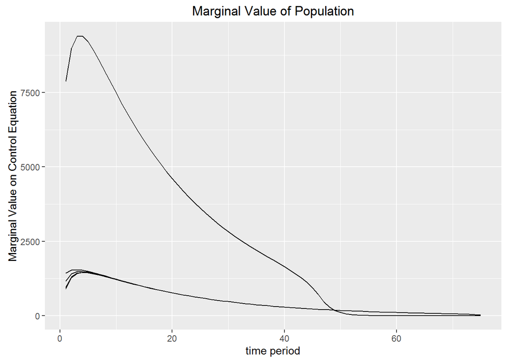

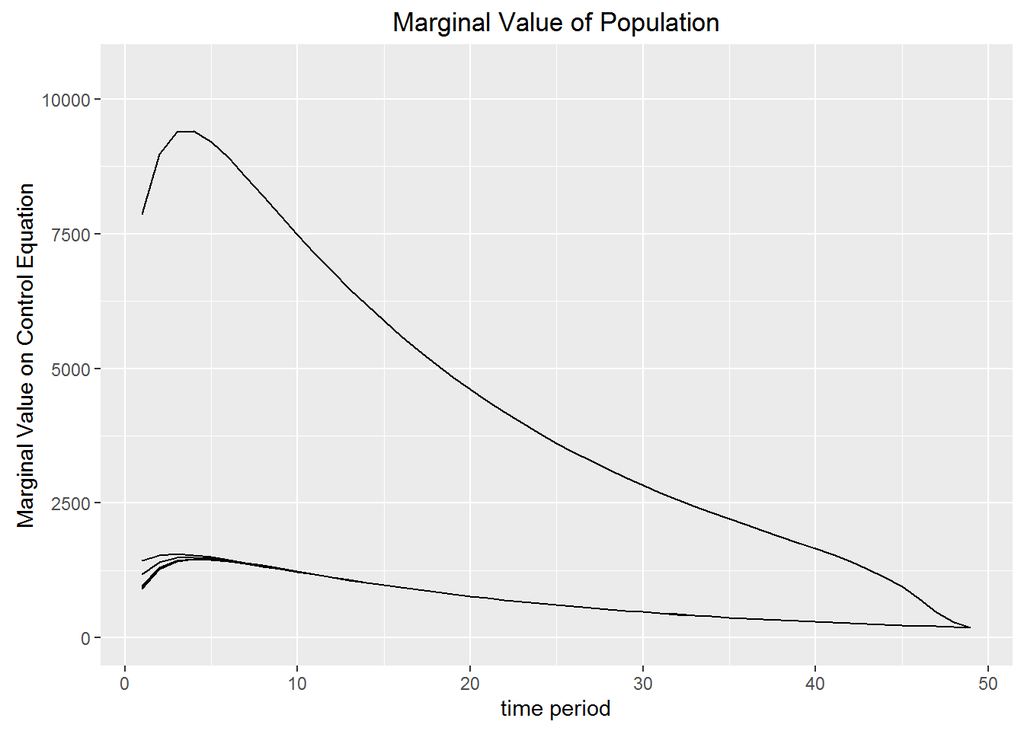

The point of this non-linear model was to approximate the cost of leaving an animal on the landscape. To that end we need to do some calculations. First, we need to think of the decision-maker in the agent-based model. In each time period that decision maker decides what to grow and how many animals to remove. That is more analagous to our time period one in the dynamic model than time zero. Time zero is more of a spin up to allow for referencing previous periods. We are arguing that the agent-based decision-maker should be concerned about what leaving one more animal on the landscape will mean for future periods. Again, with the population `control` equation, the timing is reconciling the population after reproduction, after removal efforts, prior to damage, i.e. the same schedule as the agent-based model. The agent-based decision-maker is already considering damage in the present, so we need to remove damage in the present from the model’s accounting of future costs imposed by an animal found in the `control_marginal`output of `gams`. The current period damage can be found from the derivative above and subtracted from the first period marginal obtained from the dynamic model to find the future periods damage.

$$y=Control\_Marginal(n)_{t=1}-damage'(n)$$

Corn and soybean damage marginal functions are very close at the tails and fairly close at the function’s maximum. The spirit of the test is a simplified view of future damage, so these two functions will be averaged into a single. Using `R`’s spline interpolation functionality we are able do develop a function that will find the marginal value of a single animal left alive *after* the first period. This function is then added to the Agent-Based Simulation Framework.

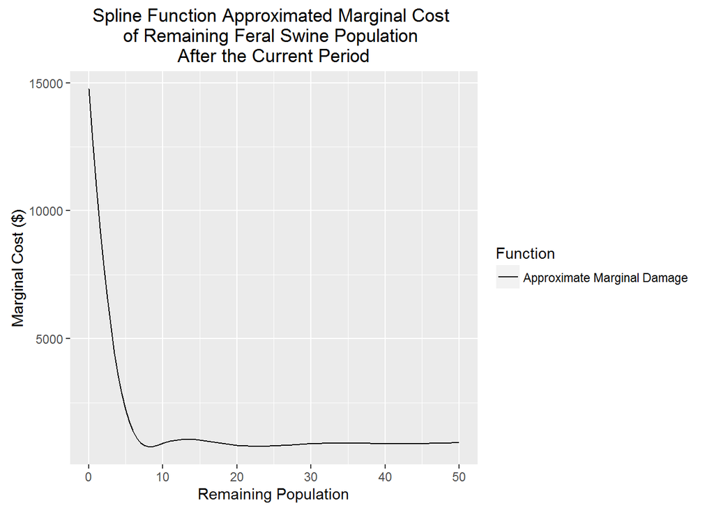

### 2.4.3 Implementation in the Agent-Based Framework

Departing from rational expectations is challenging because there are infinitely many ways to model decision-making irrationally. Therefore, we will focus on a few that fit the narrative heard when talking to producers and extension professionals and common heuristic devices.

The agents make land use choices in a linear programming framework. The agent-based framework developed here gives substanially more granularity to spatial decisions and individual personalities, however gives up granularity in choice of actions. The same three crops are choices for the agents in the agent-based model, but the agent can only choose to not control, control lightly (around 25% reduction), or control heavily (around a 90% reduction). As such, we are able to pass a truely non-linear problem as linear. The key difference between the different implementations of OCPM is in construction of the objective function.

A technical detail that is necessary to understand the forthcoming equations is that `R` is particularly adept at processing functions across vectors and less adept at for-loops and similar structures commonly used in other languages. As such, the parameters and variables are vectors, not scalars.

The implementations in the agent-based framework are as follows. We define two dimensions of producer implementation. First, “removal price method”, can be “marginal”,“minus”,or “linear.” The second is the “OCPM method.” Code implementation often refers to this as “user cost” simply because of its succinct and clear (although not totally correct) meaning. OCPM method can take values of “myopic”, “minus”, or “linear.”

A marginal removal price method implies that the decision maker evaluates the cost of removal at every increment. For example, the landowner chooses to remove the tenth animal, re-evaluates, and so on (`marginal*(incrRemovalPrice(pop_if_none,d))`) where `pop_if_none` is the current population and `d` is the proposed population. The minus removal price method implies that the producer is concerned about the difference in prices between different remaining populations. The landowner evaluates the price of removal at the current and proposed population and then multiplies the difference by the number of animals removed that implies (`minus*((removalPrice(d)-removalPrice(pop_if_none))*(pop_if_none-d))`). The linear removal price method implies that the producer evaluates the removal cost function at proposed population levels and then multiplies that price by the implied number of animals removed (`linear*(removalPrice(d)*(pop_if_none-d))`).

A myopic approach to OCPM is simply setting the OCPM to zero (`ucmyopic*(d)`). A minus approach evaluates the OCPM function at current and proposed population levels and multiplies the difference by the proposed population change (`+ucminus*(minusUserCost(pop_if_none,d))`) and views this value as a benefit to removal. Finally, a linear approach applies the value as a cost imposed by a remaining population linearly (`-uclinear*(userCostf(d)*(pop_if_none-d))`) by evaluating the OCPM at the proposed population and then multiplying it by the difference in proposed and current populations.

Each agent is assigned removal price method and an OCPM method.

```r
if(RemovalPriceMethod=="random"){
  a<-c("marginal","minus","linear")
  removalPrFnVec <- sample(a, init_hh, replace=TRUE)
}
if(RemovalPriceMethod=="linear"){
  removalPrFnVec <- rep_len("linear",length.out = init_hh)
}
if(RemovalPriceMethod=="marginal"){
  removalPrFnVec <- rep_len("marginal",length.out = init_hh)
}
if(RemovalPriceMethod=="minus"){
  removalPrFnVec <- rep_len("minus",length.out = init_hh)
}
if(UserCostMethod=="random"){
  a<-c("myopic","minus","linear")
  userCostFnVec <- sample(a, init_hh, replace=TRUE)
}
if(UserCostMethod=="myopic"){
  userCostFnVec <- rep_len("myopic",length.out = init_hh)
}
if(UserCostMethod=="minus"){
  userCostFnVec <- rep_len("minus",length.out = init_hh)
}
if(UserCostMethod=="linear"){
  userCostFnVec <- rep_len("linear",length.out = init_hh)
}
```

The damage function described above is implemented.

```r
#' @rdname WildPigABM
#' @export
pctDamFunc <- function(x){0.9 + (-0.899)/(1 + (x/14.21)^5)}
```

A removal price function is defined as described above as well as a incremental removal price function used in the case of the marginal removal price.

```r
#' @rdname WildPigABM
#' @export
removalPrice <- function(x){
  35.404 + (1464)/(1 + (x/3.299004)^1.843566)
}
#' @rdname WildPigABM
#' @export
incrRemovalPrice <- function(x,y,...){
sum(removalPrice(x:y))
}
```

The OCPM function is defined through the spline functionality of `R` described above. The minus method of approaching OCPM is done by first defining a function to difference the evaluated OCPM functions and multiply this difference by the difference in population levels.

```r
#' @rdname WildPigABM
#' @export
minusUserCost <- function(pop_if_none,pop_if,...){
  x <- pop_if_none
  y <- pop_if
  z = x-y
  (userCostf(y)-userCostf(x))*z
}
```

These, smaller, defined functions are then used in a function to develop the gross margin for each activity. Mathematically, the gross margin is defined:

$$gm = p\times(y-y \times pctDamFunc(d))-vc- \\
linear\times(removalPrice(d)\times(pop\_if\_none-d)) - \\
marginal\times(incrRemovalPrice(pop\_if\_none,d))- \\
minus\times((removalPrice(d)-removalPrice(pop\_if\_none))\times(pop_if_none-d))+ \\
ucminus\times(minusUserCost(pop\_if\_none,d))- \\
ucmyopic\times(d)- \\
uclinear\times(userCostf(d)\times(pop\_if\_none-d))$$

In `R` the objective function generating function is defined.

```r
#' @rdname WildPigABM
#' @export
estGM <- function(pop_if_none, pop_if_light, pop_if_heavy ,
                  dam_corn,dam_soy,dam_crp,
                  adjYieldCorn, adjYieldSoy,
                  P_corn, p_soy, p_crp,
                  varCost_corn,varCost_soy,varCost_crp,
                  dFnForm,Removal_Price,User_Cost,...){
  P_crp=P_CRP
  varCost_crp=verCost_CRP
  adjYieldCRP=10
# linDam <- ifelse(dFnForm=="linear",1,0) ## NOT IMPLEMENTED
# SigDam <- ifelse(dFnForm=="sigmoidal",1,0) ## NOT IMPLEMENTED
linear <- ifelse(Removal_Price=="linear",1,0)
marginal <- ifelse(Removal_Price=="marginal",1,0)
minus <- ifelse(Removal_Price=="minus",1,0)
ucminus <- ifelse(User_Cost=="minus",1,0)
ucmyopic <- 0
uclinear <- ifelse(User_Cost=="linear",1,0)


K = list("Corn","Soy","CRP")
KK = list("none","light","heavy")
for (k in 1:length(K)){
  for (kk in 1:length(KK)){
    p<-get(paste0("P_",tolower(K[[k]])))
    y<-get(paste0("adjYield",K[[k]]))
    d<-get(paste0("pop_if_",KK[[kk]]))
    vc<-get(paste0("varCost_",tolower(K[[k]])))

    gm <- p*(y-y*pctDamFunc(d))-vc-   #Net Income
      linear*(removalPrice(d)*(pop_if_none-d)) - # linear removal pricing
      marginal*(incrRemovalPrice(pop_if_none,d))- # removal price evaluated at each animal removed
      minus*((removalPrice(d)-removalPrice(pop_if_none))*(pop_if_none-d))+ #removal price is difference of evaluated price times removed animals
      ucminus*(minusUserCost(pop_if_none,d))-
      ucmyopic*(d)-
      uclinear*(userCostf(d)*(pop_if_none-d))

    nam <- paste0("gm_",tolower(K[[k]]),"_",KK[[kk]])

    assign(nam,gm)
  }
}
return(c(gm_corn_none,
         gm_corn_light,
         gm_corn_heavy,
         gm_soy_none,
         gm_soy_light,
         gm_soy_heavy,
         gm_crp_none,
         gm_crp_light,
         gm_crp_heavy ))
}
```

This gross margin generation function is used within the context of the linear programming evaluation process. The implementation of this function begins by gathering the data it needs from `NetLogo` and the global environment of `R` and then generates a vector of gross margins.

```r
#============================================================================
# All of the landowner decision making functions use the same framework.
# The only difference is the forumulation of the objective function.
# The revised dynamicish function realizes this and provides flexibility for
# mixed levels of rationality.

#' @rdname WildPigABM
#' @export
RevisedDynamicISH <- function(verboseR, t, now,today,
                       init_hh,
                       P_corn,P_soy,P_CRP,
                       varCost_corn, varCost_soy,verCost_CRP,
                       removalPrFnVec,userCostFnVec,typeDecision,
                       ...) {
    ## NL has all it needs
    RNetLogo::NLCommand('dynamic-prep-step1')
    Sys.sleep(2)
    landownersolution <- list()
    #start looping
    for (j in 1:init_hh) {
      hh <- j - 1
      if (verboseR == TRUE) {print(paste("hh=", hh))}
      patchset <- paste("patches with [owner = ",hh,"]")
      dat <- RNetLogo::NLGetPatches(c(
        "pxcor", "pycor",'pop_if_none',
        'pop_if_light',
        'pop_if_heavy',
        'adjYieldCorn',
        'adjYieldSoy',
        "pigTerritoryStrength"),
        patchset)
      Sys.sleep(2)

      pigTerritoryStrength <- as.vector(dat$pigTerritoryStrength)
      pop_if_none <- as.vector(dat$pop_if_none)
      pop_if_light <- as.vector(dat$pop_if_light)
      pop_if_heavy <- as.vector(dat$pop_if_heavy)
      adjYieldCorn <- as.vector(dat$adjYieldCorn)
      adjYieldSoy <- as.vector(dat$adjYieldSoy)

      #========== eval marginal cost at current, and cost at proposed population subtract
      #fun.6
      #usercost
      #f
      #set gross margins

      obj <- estGM(pop_if_none=pop_if_none,
                   pop_if_light=pop_if_light,
                   pop_if_heavy=pop_if_heavy,
                   dam_corn=dam_Corn,
                   dam_soy=dam_soy,
                   dam_crp=dam_CRP,
                   adjYieldCorn=adjYieldCorn,
                   adjYieldSoy=adjYieldSoy,
                   P_corn=P_corn,
                   P_soy=P_soy,
                   P_crp=P_CRP,
                   varCost_corn=varCost_corn,
                   varCost_soy=varCost_soy,
                   varCost_crp=verCost_CRP,
                   dFnForm=NULL,
                   Removal_Price=removalPrFnVec[j],
                   User_Cost=userCostFnVec[j])
```

## 2.5 Landowner Income and Wealth

Landowners income and wealth are tracked over the course of the simulation. Income is calculated:
$$Income_j = \sum_i\sum_k GM_{i,k}\times use_{i,k}.$$

Note that the landowner only recieves income on what actually happened. Many calculations preceed this to reflect the state of feral swine. From the `masterSchedule`:

```
RNetLogo::NLCommand('go-wrap-up-myopic')
```

In spite of the command’s name, it is used for all four decision types. This function calls a number of `NetLogo` functions.

```
to go-wrap-up-myopic
  ;myopic-income
  real-income
  calculateHHIncome
end
```

```
to real-income
    count_and_claim
  ask patches [
    let none  0
    let light (pigTerritoryStrength * 0.25)
    let heavy (pigTerritoryStrength * 0.90)
    set tempCornDam    0.9 + (-0.899) / (1 + (pigTerritoryStrength / 14.21) ^ 5)
    if tempCornDam > 0.999 [set tempCornDam 0.999]
    set tempSoyDam     0.9 + (-0.899) / (1 + (pigTerritoryStrength / 14.21) ^ 5)
    if tempSoyDam > 0.999 [set tempSoyDam 0.999]
    set removal_none   0
    set removal_light  (35.404 + (1464) / (1 + (pigTerritoryStrength / 3.299004) ^ 1.843566))  * light
    set removal_heavy  (35.404 + (1464) / (1 + (pigTerritoryStrength / 3.299004) ^ 1.843566))  * heavy

    set tkcount count tk

    if a_corn_none > 0  [
      set parcel_NI P_corn * adjYieldCorn * (1 - tempCornDam) - varCost_corn + removal_none + tkcount * bounty
      ]
    if a_corn_light > 0 [
      set parcel_NI P_corn * adjYieldCorn * (1 - tempCornDam) - varCost_corn + removal_light + tkcount * bounty
      ]
    if a_corn_heavy > 0 [
      set parcel_NI P_corn * adjYieldCorn * (1 - tempCornDam) - varCost_corn + removal_heavy + tkcount * bounty
      ]

    if a_soy_none > 0  [
      set parcel_NI P_soy  * adjYieldSoy * (1 - tempSoyDam) - varCost_soy + removal_none + tkcount * bounty
      ]
    if a_soy_light > 0 [
      set parcel_NI P_soy  * adjYieldSoy * (1 - tempSoyDam) - varCost_soy + removal_light + tkcount * bounty
      ]
    if a_soy_heavy > 0 [
      set parcel_NI P_soy  * adjYieldSoy * (1 - tempSoyDam) - varCost_soy + removal_heavy + tkcount * bounty
      ]

    if a_crp_none > 0  [
      set parcel_NI P_CRP  * 10 - verCost_CRP + removal_none + tkcount * bounty
      ]
    if a_crp_light > 0 [
      set parcel_NI P_CRP  * 10 - verCost_CRP + removal_light + tkcount * bounty
      ]
    if a_crp_heavy > 0 [
      set parcel_NI P_CRP  * 10 - verCost_CRP + removal_heavy + tkcount * bounty
      ]
    output-show (sentence "parcel_NI:" parcel_NI
                         "pigTerritoryStrength" pigTerritoryStrength
                         "removal_none" removal_none
                         "removal_light" removal_light
                         "removal_heavy" removal_heavy
                         "tempCornDam" tempCornDam
                         "tempSoyDam" tempSoyDam
                         "a_corn_none" a_corn_none
                         "a_corn_light" a_corn_light
                         "a_corn_heavy" a_corn_heavy
                         "a_soy_none" a_soy_none
                         "a_soy_light" a_soy_light
                         "a_soy_heavy" a_soy_heavy
                         "a_crp_none" a_crp_none
                         "a_crp_light" a_crp_light
                         "a_crp_heavy" a_crp_heavy)

  ]
end
```

The third operation collects income on patches owned by each individual.

```
to calculateHHIncome
  ask households [
    let aa sum [parcel_NI] of patches with [owner = [hh_num] of myself]
    set HH_income aa
    set wealthi wealthi + HH_income
    show (sentence "HH_income" HH_income "Weath" wealthi)
    ]

end
```

This income information is sent to `R` for reporting.

```r
wealthi <- cbind(wealthi,RNetLogo::NLGetAgentSet('wealthi', 'households', as.data.frame = TRUE))
...
names(wealthi) <- paste0("t",0:max_cycles)
  wealthi$id <- 1:45
  wealthi <- reshape::melt(wealthi,id.vars="id")
  wealthi$sim <- paste("sim",typeDecision,generic_removal_price,realistic,sep = "_")
```

## 2.6 Feral Swine Damage

If one were to simply find the net present value or discounted sum of future damages (see Moss 2013, ch. 5), the effect of progeny would be missed. If damage was inflicted linearly (such as in Zivin, Hueth, and Zilberman (2000)), we could use a formula for present value of a perpetuity, $PV=\frac{PMT}{r-g}$, where $PV$ is present value, $PMT$ is the annual cash flow inflicted by feral swine, $r$ is the discount rate, and $g$ is the annual population growth rate. However, while the exact functional form is unknown, a linear damage function does not follow the narrative that we hear from producers and does not make logical sense.

A non-linear damage function fits the known behavior of feral swine. First, the damage function must be able to handle populations greater than estimated carrying capacity. In Zivin, Hueth, and Zilberman (2000) the function is based on full damage of 90% being carried out by a population of 15 animals.

> Damage to rangeland, measured as a percentage loss of total revenue, is modeled as a linear function of pig population density (Barrett [16]):
> $$D(N) = cN$$
> Data and information on rangeland damage were collected from a number of studies (Barrett et al. [10], Sterner and Barrett [12], Barrett [17]). Based on this information, and through conversations with Barrett [16], $c$ was set equal to 0.06. This implies that at full carrying capacity (15 pigs/km2), total rangeland damage is 90%. Because there is considerable uncertainty associated with this parameter, we vary this coefficient and examine its impact on steady-state results. (Zivin, Hueth, and Zilberman 2000, 197–98)

Additionaly, a linear reduction in population is almost certainly not optimal from an optimal management perspective. This is what is found here, discussed later in the estimation portion of this discussion, and is typical in these types of problems. A reasonable followup question to this statement is, why not just use a planning technique that will produce optimal management?

We want to abstract away from an optimal management scenario to test differing levels of adherance to expert opinion. For instance, if one were to hire a consultant or ask for assistance from an extension agent about their feral swine problem, they would likely not be presented with a fully optimal management plan that accounts for movement, reproduction, resistance to control measures, the particular damage function of that farm, etc. The producer would be presented with a rule of thumb or may be presented something more complex and then act on it inappropriately. As discussed earlier, one person’s mismanagement or refusal to cooperate will have consequences beyond their property borders. If we can condence the essence of an optimal management plan and then test different implementations of that management plan we can address this communication issue. As discussed earlier, there is a maximum level of damage and that when the population changes, damage changes non-linearly. These ideas can be fitted to a sigmoidal curve. A symmetric sigmoidal curve set to be very near zero at a population of zero and to max out at 90% damage at a full population of 30 head in the 2km^2 area.

$$y=0.9 + (-0.899)/(1 + (x/14.21)^5)$$

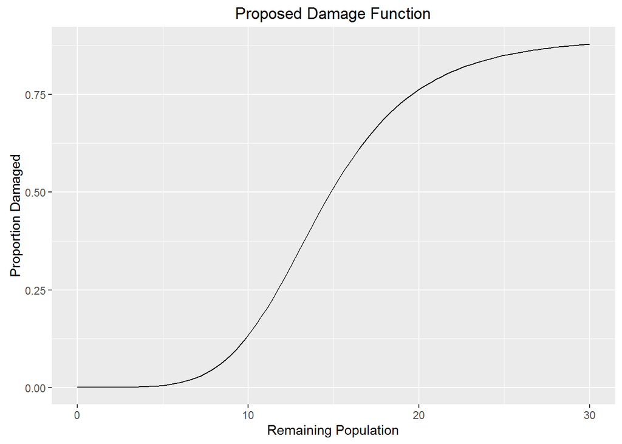

#### 2.6.0.1 Marginal Conditions

Both control and damage are a function of remaining population, rather than control effort. In addition, benefit is an avoided cost. They are two sides of the same coin, however, a subtle shift in interpretation of the marginal conditions is required. First, find the marginal damage for corn and soybeans.

$$\text{differentiate } damage_{corn} = (0.9 - 0.899/(1 + (x/14.21)^5)) \times 1350 \times 3.71 \text{ w.r.t. x}$$

$$damage_{corn}'(x) = (1.30439×10^{10} \times x^4)/(x^5 + 579389)^2$$

$$\text{differentiate } damage_{soy} = (0.9 - 0.899/(1 + (x/14.21)^5)) \times 450 \times 9.15 \text{ w.r.t. x}$$

$$damage_{soy}'(x) = (1.07234×10^{10} \times x^4)/(x^5 + 579389)^2$$

Then the cost of achieving a remaining population. There are more benefits to removal than the single season. We should include future benefits. It is unclear how long a decision-maker will plan, however, a perfect planner would look forward infinitely. The present value of a perpetuity is:

$$PV=PMT/r$$

where $PV$ is present value, $PMT$ is a payment, and $r$ is a dicount rate.
$$damage_{corn, perpetuity}'(x)= (2.60878x10^{11} x^4)/(x^5 + 579389)^2$$
$$damage_{soy, perpetuity}'(x) = (2.14469x10^{11} x^4)/(x^5 + 579389)^2$$

Damage is calculated both before during the landowner planning phase (`dynamic-prep-step1`) and at the end of the period (`myopic-income`). Each time damage is a function of feral swine presence. Presence is a essentially a count of full and partial days of pig presence. Illustrated in the figure below, we see a center patch with several feral swine located on it. That patch should have a presence of $n \times 1$, the four red patches around that will have a presence of $n \times 1 / 4$, the eight light blue patches outside of that have a presence of $n \times 1 / 8$, the 16 patches outside of that have a presence of $n \times 1 / 16$, the lighter blue patches outside of those have a presence of $n \times 1/32$, and the green patches in the corners are untouched. If the range is increased, the impact continues to halve each distance outward.

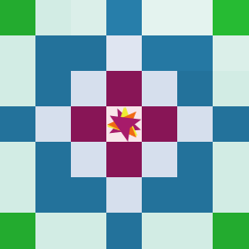

Example Feral Swine Presence

Applying this idea (with different colors) to the entire map in the figure below we see how presence compounds between animals across space. Crop damage varies greatly by state and likely by specific areas within states. Anderson et al. (2016) found between 0.83% and 4.73% of corn and between 0.02% and 3.43% of soybeans are lost to feral swine damage. It is quite likely that damage is highly localized, meaning that where damage occurs it is intense, but there are vast areas without substantial damage as well. It is unlikely that damages would be this low if feral swine presence was at 100% of capacity.

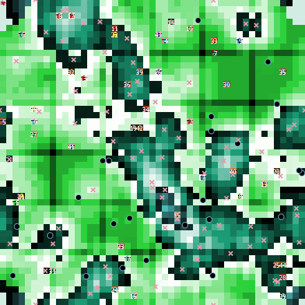

Example Feral Swine Presence - Entire Map

Zivin, Hueth, and Zilberman (2000) implies that each pig creates 6% damage on an area of $1 \ km^2$. On that scale, this may be a high estimate on a per-pig basis. For the purposes of this we will assume that 1 pig spending a whole year on a ten acre plot will cause 2.37% damage to corn and 1.71% damage to soybeans. This is a more conservative estimate when evaluated on the same scale as Zivin, Hueth, and Zilberman (2000).

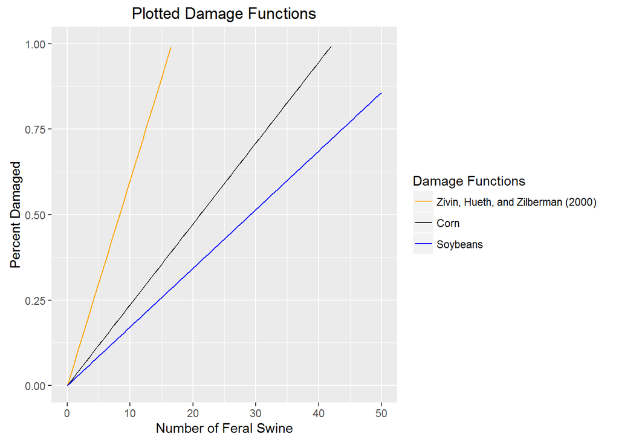

Crop Damage Functions Plotted.

Alternatively, damage could be modeled based on Hone (1995). This approach should be parameterized for the United States, but certainly demonstrates the shape of what the damage function should be in a more complex representation. Hone (1995) found that there is a curvilinear relationship between the extent of rooting and freqency of rooting and feral swine density. The plots below demonstrate the curvature found when a measure of pig density (x) with one more measure for each line is regressed on the change in frequency of rooting.

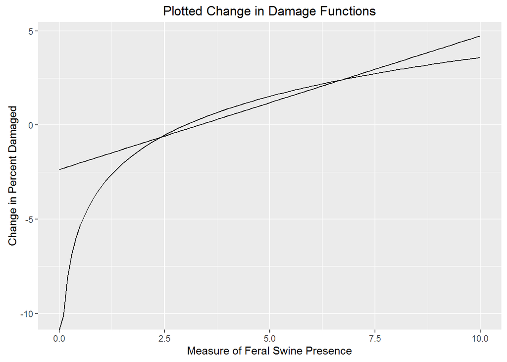

Change in Damage as a Function of Feral Swine Density. Source: Hone (1995).

### 2.6.1 Implementation of Crop Damage

In the planning stages, crop damage is calculated by the `dynamic-prep-step1` function. The relevant excerpt below shows that a prediction of population after each kind of action is calculated and this value is used to calculate an expected yield contingent upon the action chosen.

```
...
    set no_damage_corn_GM P_corn * adjYieldCorn - varCost_corn
    set no_damage_soy_GM  P_soy  * adjYieldSoy - varCost_soy
    set pop_if_none     pigTerritoryStrength * (1 - none)
    set pop_if_light    pigTerritoryStrength * (1 - 0.25)
    set pop_if_heavy    pigTerritoryStrength * (1 - 0.90)
    set dam_corn_none   dam_Corn * pop_if_none
    set dam_corn_light  dam_Corn * pop_if_light
    set dam_corn_heavy  dam_Corn * pop_if_heavy
    set dam_soy_none    dam_Soy  * pop_if_none
    set dam_soy_light   dam_Soy  * pop_if_light
    set dam_soy_heavy   dam_Soy  * pop_if_heavy
    set yield_corn_none     adjYieldCorn * (1 - dam_corn_none)
    set yield_corn_light    adjYieldCorn * (1 - dam_corn_light)
    set yield_corn_heavy    adjYieldCorn * (1 - dam_corn_heavy)
    set yield_soy_none      adjYieldSoy  * (1 - dam_soy_none)
    set yield_soy_light     adjYieldSoy  * (1 - dam_soy_light)
    set yield_soy_heavy     adjYieldSoy  * (1 - dam_soy_heavy)
    ...
```

Similarly, at the income calculation stage (`myopic-income`), damage is calculated based on the actual presence at harvest.

```
to myopic-income
...
    set tempCornDam  dam_Corn * pigTerritoryStrength
    set tempSoyDam   dam_Soy  * pigTerritoryStrength
...
    if a_corn_none > 0  [
      set parcel_NI P_corn * adjYieldCorn * (1 - tempCornDam) - varCost_corn + removal_none
      ]
    if a_corn_light > 0 [
      set parcel_NI P_corn * adjYieldCorn * (1 - tempCornDam) - varCost_corn + removal_light
      ]
    if a_corn_heavy > 0 [
      set parcel_NI P_corn * adjYieldCorn * (1 - tempCornDam) - varCost_corn + removal_heavy
      ]

    if a_soy_none > 0  [
      set parcel_NI P_soy  * adjYieldSoy * (1 - tempSoyDam) - varCost_soy + removal_none
      ]
    if a_soy_light > 0 [
      set parcel_NI P_soy  * adjYieldSoy * (1 - tempSoyDam) - varCost_soy + removal_light
      ]
    if a_soy_heavy > 0 [
      set parcel_NI P_soy  * adjYieldSoy * (1 - tempSoyDam) - varCost_soy + removal_heavy
      ]

    if a_crp_none > 0  [
      set parcel_NI P_CRP  * 10 - verCost_CRP + removal_none
      ]
    if a_crp_light > 0 [
      set parcel_NI P_CRP  * 10 - verCost_CRP + removal_light
      ]
    if a_crp_heavy > 0 [
      set parcel_NI P_CRP  * 10 - verCost_CRP + removal_heavy
      ]
```

## 2.7 Feral Swine Grouping

Grouping of feral swine is a known phenomena. The exact mechanism is unknown, but it is believed to be important in modeling their behavior. As such we have a simple first pass attempt. An agent is initialized for the purpose of being the focal point of a sounder.

```
sounders-own [
  sounder_id
  age
  scount
]
```

The actual creation is carried out during the `setup` process. The agent has an age, identification, and can store a count of sows who are members.

```
to setup-sounders
  create-sounders init_sounder
  [
  set age 0
  set sounder_id who
  set scount 0
  ]
end
```

Movement functions (documented in “Feral Swine Movement”) and a function governing the splitting of large sounders are the only current use of this idea. `splitTheSounder` splits sounders that get larger than a user defined maximum size of sounder.

```
to splitTheSounder
  if any? sounders [
  let zz (maxSounderN + ALLOWABLEOVERCAP)
  ask sounders [
    set scount count sows with [sounder_id = [sounder_id] of myself]
    if scount > zz [
      let oldme who
      hatch-sounders 1 [
        set age 0
        set sounder_id who
        let sid sounder_id
        let op scount - zz
        ask n-of op sows with [sounder_id = oldme]
        [
          set sounder_id sid
          ]
      ]
    ]
  ]
  ]
end
```

## 2.8 Feral Swine Movement

Movement is a complicated process and is the strength of the `NetLogo` platform. The first step is to establish the attractiveness of each patch based on quality, last year’s removal pressure, and relative population.
$$\text{Attractiveness}_i = f(\frac{1}{\text{Relative Pop. Density}_i},Quality_i, \frac{1}{\text{Previous Year Removal Pressure}_i})$$

```
to prepareToMove
  ; land desirability is
        ;inversely related to population
        ;inversely related to pressure
        ;inversely related to other sounder's territory strength
        ;positively related to quality
     count_and_claim
     let maxperpatch (max_pigs / total_patches)
  ask patches[
    ; find patch populations, set as proportion to full capacity

    let mapPopulation boarCount + sowCount
    let x (mapPopulation / maxPigsPerPatch)
    ; recall quality
    let z quality
    ; establish attractiveness pre-land claim (additive)
    let tempattr ((1 / (x + 2.22e-16)) + (z))
    ; recall psi t-1
    let y psi_lastPeriod
    ifelse y < 0.01 ; inverse epsilon small numbers are very big and that is
    ;nonsense anyway
    [set PatchAttractivenessPriortoLandClaim tempattr]
    [set PatchAttractivenessPriortoLandClaim (tempattr + (1 / (y + 2.22e-16)))]
  ]
end
```

Movement of sounders is the most complicated movement. Each time through the sounders claim territory and then move according to their movement function. Each sounder is intended to move away from other sounders. Later generations will build on the loop structure commented out as timesteps are narrowed.

```
to move-sounders
  if any? sounders [
    let nb num_bases_per_year
    ;foreach n-values 5 [ ? + 1 ][
  ;set over-all attractiveness of patches
    prepareToMove
  ;set current territory
  ;evaluate attractiveness for each sounder ;sounders move
    ask sounders [
      let tempPig sounder_id
      ask patches in-radius srange [
        let nm (int sounderTerritory - int tempPig) ^ 2
        ifelse nm > 0 [set notmine 1][set notmine 0]
        set localsounderTerritoryStrength sounderTerritoryStrength * notmine
        set localAttractiveness (PatchAttractivenessPriortoLandClaim - localsounderTerritoryStrength)
        if localAttractiveness < 0.001 [set localAttractiveness 0]
        ]
      let ideal-site max-one-of patches in-radius srange [localAttractiveness]
      move-to ideal-site
      if any? sows with [sounder_id = [sounder_id] of myself]
      [
        ask sows with [sounder_id = [sounder_id] of myself][
          move-to sounder tempPig
          ]
        ]
      ]
    ;rinse and repeat
    ;]
  ]
end
```

Boars move for similar reasons. By not having to move in concert, the boar movement function is much simpler.

```
to moveBoars
  if any? boars [
    ask boars [
      let b brange
      ask patches in-radius brange [
        set localsounderTerritoryStrength sounderTerritoryStrength * notmine
        set localAttractiveness (PatchAttractivenessPriortoLandClaim - localsounderTerritoryStrength)
        if localAttractiveness < 0.001 [set localAttractiveness 0]
      ]
      let ideal-site max-one-of patches in-radius b [localAttractiveness]
      move-to ideal-site
    ]
  ]
end
```

## 2.9 Feral Swine Removal Pricing

Depending on the simulation, it may make sense to price removal in different ways.  
The removal of feral swine is increasingly difficult as the population approaches zero. The most extreme statement of this is:

$$\lim_{n\to0} w_{control}(n) \ \to L .$$

There have been successful eradication campaigns, so the price of removal to zero is not infinite. Saunders and Bryant (1988) proposed a removal cost function based on flight time used in an exercise in Australia,

> p = 1 - 1.177exp(0.001375t). With one helicopter we can assume an average of 400 min flying time per day. To remove 95% of the population would have therefore taken the exercise to 7 days (2297 min). Similarly, a 99% reduction would take 9 days (3468 min). (Saunders and Bryant 1988, 78)

Wildlife managers understand the increasing cost of removal, but they also understand the need to communicate average costs. That is, we know that we are currently removing something close to 20-30% of the feral swine in Texas (Carson 2013) and mixed removal actions in Texas cost approximately $65/head (Bodenchuk 2014). If we solve the equation proposed by Saunders and Bryant (1988) for $t$, we find:

$$t = 8000/11 \times ln(-100/177 \times (p-1)) \ for \ p<1.$$

However, what we really need is a pricing mechanism for professional removal that reflects the increasing difficulty of removing as the population reaches zero. A function like the one below reflects the price we currently face with abundant populations and approaches the theoretical price curve proposed by Saunders and Bryant (1988).

$$w_{control}=35.404 + (1464)/(1 + (x)/3.299004)^{1.843566})$$

Plotted, this function retains the shape of Saunders and Bryant (1988) but instead works off of the expected remaining population and calibrates to approximate twenty percent removal at approximately $65/head and removal of the last animal at approximately $1500.

Alternatively, it could be modeled that each type of removal has a different cost or revenue associated with it. The sections below detail how that could be carried out.

### 2.9.1 Price consumers are willing to pay to hunt.

We do not know much about pricing of commercial feral swine hunts. We can gather from Hainds (2011) that about $300 is the going rate for a certain, ground based, kill. It seems reasonable to assume that at some threshold of density a kill is practically guaranteed on average. Lets call that threshold `minPigsFee`. For the moment, lets say that there is nothing more valuable than the guaranteed kill, so this $300 is a minimum of a day of hunting and a minimum of a single kill. Obviously, there are a number of factors such as operating as a bed and breakfast that would add value and possibly add to willingness to pay. Those factors are beyond the immediate scope of the study.

A price function such as:

$$p=260 * ln(n^{1/2})$$

where $p$ is the price of a hunt and $n$ is the population on a parcel (patch) of property. This function reaches the price of $300 per hunt when the property has at least ten head (per ten acres), equal to `minPigsFee`.

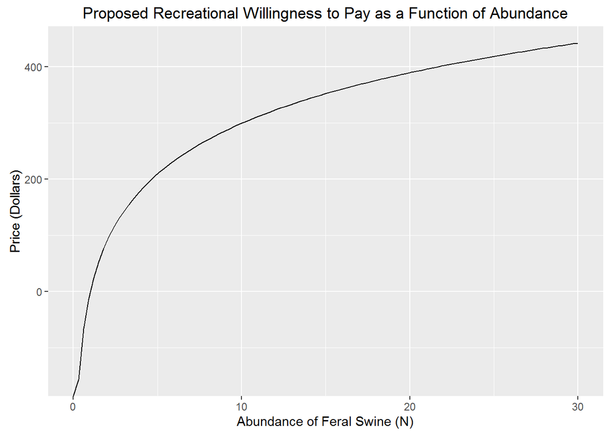

### 2.9.2 Cost of removal effort by paid professionals.

We can use $65 per head (Bodenchuk 2014) as a starting place for the cost of removing feral swine. However, we know that it is progressively more expensive to remove swine as fewer remain on a parcel. Saunders and Bryant (1988) document the cost of an eradication effort in Australia. No such study exists for the US to the knowledge of the authors. This is likely not a correctly calibrated parameterization for the United States as the study area was a very large open area. The environment in some places in the US might be quite similar, however, a smaller wooded area would have different results. In any case the curvature describes what is anecdotely known about the cost of removing a large proporion of the animals in a given area; Saunders and Bryant (1988) found:

> p = 1 - 1.177exp(0.001375t). With one helicopter we can assume an average of 400 min flying time per day. To remove 95% of the population would have therefore taken the exercise to 7 days (2297 min). Similarly, a 99% reduction would take 9 days (3468 min). (Saunders and Bryant 1988, 78)

We do not necessarily know how many animals are desired to be removed *a priori*, However, ecologists are able to estimate what proportion of full population is present. If we work from that standpoint, and say that we know full capacity is `max_pigs`/`total_patches` and the landowner is able to perceive that there is a presence of `sounderTerritoryStrength`+`boarTerritoryStrength` on a given patch. If we solve Saunders and Bryant’s equation for $t$ we get:
$$t = 8000/11 \times ln(-100/177 \times (p-1)) \ for \ p<1.$$
If we set $(-1 * `sounderTerritoryStrength`+`boarTerritoryStrength`) = p$ we could then multiply the time required by the price of helicopter rental until a more exact number can be found. This would bring mean the cost function would be approximately:
$$varCost_{Paid} = (8000/11 \times ln(-100/177 \times (p-1))) * pMinuteFlight) \ for \ p<1.$$
We can implement this in `R` and `NetLogo` using the cost of rental for training hours of $261/hr. This works out to $4.35/minute.(http://www.flyhaa.com/helicopter/costs/details/)

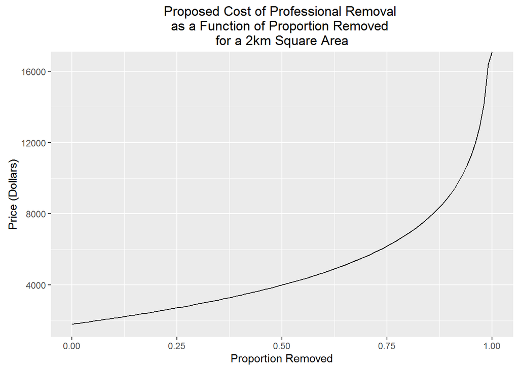

#### 2.9.2.2 Professional Removal as a Function of Remaining Population

However, what we really need is a pricing mechanism for professional removal that reflects the increasing difficulty of removing as the population reaches zero. A function like the one below reflects the price we currently face with abundant populations and approaches the theoretical price curve proposed by Saunders and Bryant (1988).
$$p=35.404 + (1464)/(1 + (x)/3.299004)^{1.843566})$$
Plotted, this function retains the shape of Saunders and Bryant (1988) but instead works off of the expected remaining population.

Parameterizing any of these functions based on some form of data would be ideal. This will have to suffice until that can be done.

## 2.10 Feral Swine Removal

Survival of an individual is a function of harvest effort among other factors (Hanson et al. 2009). Sex, season, weight, and age were other factors used to predict the survival of individuals (Hanson et al. 2009). Parameters for Hanson et.al. (2009)’s models were not published so the precise relationship between those variables and survival is unknown. We also know (at least anecdotely) that swine respond to removal effort. We will model the probability of an individual feral swine removal as
$$pr(Removal_i)=f(\text{current effort}, \text{previous effort experienced by individual}, \text{chance}).$$

### 2.10.1 Landowner Removal

Landowners choose to remove feral swine when
$$benefit \geq cost$$
purely in pecuniary terms. Non-pecuniary benefits could be easily added through a price mechanism. Removal effort is represented through the variable `Psi` or $\Psi$. First, the wild pigs are counted on home territory. Landowners are aware of the cumulative presence of wild pigs on each patch they control through `pigTerritoryStrength` and choose their actions based on this knowledge. However, removal is based upon actual presence on a patch. The implication is that the landowner must choose to remove on the wild pig’s home patch in order to actually harvest an animal. Scheduling is carried out in the `masterSchedule()` function. Within this function, count is updated, `Psi` is calculated, and wild pigs are removed.

```r
### Update FS CageynessFS Breed and Move ------------------------------------------------------------------------------------
    RNetLogo::NLCommand('go-pigops')
    if (gui == TRUE){
      readline(prompt="Press [enter] to continue")
    }
    RNetLogo::NLCommand('go-myopic-removal')
    if (gui == TRUE){
      readline(prompt="Press [enter] to continue")
    }
```

Counting is documented in the `processing-functions` documentation. `Psi` is calculated in the `NetLogo` function `go-pigops`.

```
to go-pigops
  scarePigs
  breedR
  countFSTerritoryStrength
  move-sounders
  moveBoars
  splitTheSounder
end
```

The `scarePigs` function operationalizes the idea that exposure to removal pressure will make animals more responsive to future control efforts and thus less likely to be removed. This cageyness has a decay function, here each year only if cdecay equals 4, 25% of last year’s cageyness will carry into this year and 50% of last year’s experiences will be incorporated into this year’s cageyness.

$$\_cagey = \frac{1}{cdecay} \times \_cagey + \frac{1}{2} \times psi\_lastPeriod_i$$

```
to scarePigs
   if any? sows [
     ask sows [
       set scagey 1 / cdecay * scagey + [1 / 2 * psi_lastPeriod] of patch-here
     ]
   ]
    if any? boars [
     ask boars [
       set bcagey 1 / cdecay * bcagey + [1 / 2 * psi_lastPeriod] of patch-here
     ]
    ]
end
```

Breeding (`breedR`) is covered in the Feral Swine Reproduction chapter and the remaining functions are covered in the Movement chapter. The rest of the removal functions are carried out in the `go-myopic-removal` function. The ‘myopic’ in the name of the function has no bearing on its actual function. The function was created for a specific operation, and has proven useful in many later cases.

```
to go-myopic-removal
  myopic-calcPsi
  goRemoveBoars
  goRemoveSounders
  countDead
end
```

The count is taken in the `goPigOps` function and that count is used for the removal functions as well. `Psi` is then calculated for each patch based on landowner decisions. Effort is measured by `Psi` and is simply chosen by the decision-maker for each patch in each time period. The implication is that effort is constrained to fall roughly between zero and one. The goal of each of these operations is to build a probability of removal for each animal.
$$\Psi=[0,...,0.999]$$
The second to last line is a defensive programming technique to prevent an inadvertant setting of `Psi` above its defined range.

```
to myopic-calcPsi
  ask patches [
    if a_corn_none > 0  [
      set psi a_corn_none * 0
      ]
    if a_corn_light > 0 [
      set psi a_corn_light * 0.25
      ]
    if a_corn_heavy > 0 [
      set psi a_corn_heavy * 0.90
      ]

    if a_soy_none > 0  [
      set psi a_soy_none * 0
      ]
    if a_soy_light > 0 [
      set psi a_soy_light * 0.25
      ]
    if a_soy_heavy > 0 [
      set psi a_soy_heavy * 0.90
      ]

    if a_crp_none > 0  [
      set psi a_crp_none * 0
      ]
    if a_crp_light > 0 [
      set psi a_crp_light * 0.25
      ]
    if a_crp_heavy > 0 [
      set psi a_crp_heavy * 0.90
      ]
   if psi > .999 [set psi .999]
   print psi
  ]
end
```

Probability removed is then set for each animal on the map. The appropriate cagey variable modifies the pressure experienced by each individual in the current period. As stated above,
$$Pr(Removal)_{pig}=f(\text{current effort}, \text{previous effort experienced by individual}, \text{chance}).$$

The element of previous effort experienced by individual a pig, captured by `bcagey` and `scagey`, is added to an individual probability for each animal `PrRemoved` in the function below.

```
to setPrRemoved
  if any? boars [
    ask boars [
      set mypsi [psi] of patch-here
      set prRemoved (mypsi - mypsi * bcagey)
    ]
  ]
  if any? sows [
    ask sows [
      set mypsi [psi] of patch-here
      set prRemoved (mypsi - mypsi * scagey)
    ]
  ]
end
```

Once each animal has its own probability of removal, each boar and sow is presented with an opportunity to be removed. Once removed, a hidden agent is created for tracking purposes. Probability of removal is not sufficient for removal. If the threshold is met, the animal is removed. In this function, each animal is presented individually with a probability of removal. The $chance$ component of the probability of removal is implemented at this point. A random draw from a uniform distribution $U(0,1)$ is compared to `prRemoved` and if it is less than the `prRemoved` the animal is removed. For example if $prRemoved = 0.75$ there would be a nearly 75% chance that a random draw, $x \in [0,1] < 0.75$.

```
to goRemoveBoars
  if any? boars[
    ask boars [
      let rn random-float 1.0
      show (sentence "prRemoved" prRemoved "bcagey" bcagey "rn" rn)
      if rn < prRemoved [
      hatch-killed 1 [ht]
      hatch-tk 1 [ht]
      die
      ]
      ]
    ]
end

to goRemoveSounders
  if any? sows[
    ask sows[
      let rn random-float 1.0
      show (sentence "prRemoved" prRemoved "scagey" scagey "rn" rn)
      if rn < prRemoved [
        hatch-killed 1 [ht]
        hatch-tk 1 [ht]
        die
        ]
      ]
    ]
end
```

## 2.11 Feral Swine Reproduction

Modeling on an annual timestep we do not necessarily need the the actual birthrate and natural deathrate. We should be able to combine those into a single variable: `effectiveBirthRate`. If it is known that we have to kill between 60% and 80% per year to keep the stable what does this mean for an effective reproductive rate? Population in period t is the previous period’s population plus the previous period’s population times an effective birthrate minus the previous year’s population times a removal rate.

$$pop_t = pop_{t-1} + pop_{t-1} \times effectiveBirthRate - pop_{t-1} \times removalRate$$
if:
$$pop_t = pop_{t-1}$$
then
$$pop_{t-1} = pop_{t-1} + pop_{t-1} \times effectiveBirthRate - pop_{t-1} \times removalRate$$
solve for $effectiveBirthRate$
$$1 = 1 + effectiveBirthRate - removalRate$$
which means that if
$$\begin{align}
pop_t &= pop_{t-1} \\
\text{then}& \\
removalRate &= effectiveBirthRate
\end{align}$$

So by this logic we can expect each pig (male or female) to produce 0.6 - 0.8 offspring per year. Since only females have offspring, lets solve again to account for that.

$$\begin{equation}
0 = pop_{t-1} \times ProportionFemale \times effectiveBirthRate - pop_{t-1} \times removalRate
\end{equation}$$
$$\begin{equation}
\frac{removalRate}{ProportionFemale} = effectiveBirthRate
\end{equation}$$

So if 75% of feral swine are female and it requires 60% removal to maintain a stable population then we can expect
$$60/75=0.8$$
offspring per year. This rate appears to be in line with previous literature (Bieber and Ruf 2005; Geisser and Reyer 2005).

We can represent this with a default litter.

```r
defaultLitter = msm::rtnorm(1,mean=0.8, sd=1*sdMult,lower=0,upper=1)
```

Further, swine on better patches will have higher fecundity than those on worse patches, however the magnitude of the effect depends on the landscape in question [Bieber and Ruf (2005);geisser2005]. Removal pressure will also impact the ability of sows to produce viable adults, although the magnatude of this effect is less well known.

```r
#' @rdname WildPigABM
#' @export
breedR <- function(verboseR,psi_lastPeriod,...){
  NL_pushToMap("psi_lastPeriod",psi_lastPeriod[,,1],nl.obj = NULL)
  RNetLogo::NLCommand('breedR')
  if (verboseR == TRUE) {print("pigs reproduced")}
}
```

```
to breedR
  countPigs
      ask sows
      [
        let qu [quality] of patch-here
        let psil [psi_lastPeriod] of patch-here
        let al (1 - pigCountSum / (max_pigs)) * defaultLitter
        let al2 (al * (1 + qu - psil))
        let boarLitter round (al2 * sexRatio  + random-float 0.75)
        let sowLitter round (al2 * (1 - sexRatio))
        hatch-boars boarLitter [set age 0]
        hatch-sows sowLitter
        [
          set age 0
          ]
]
end
```

The resulting population trends when feral swine are not controlled appear to follow an expected population trend.

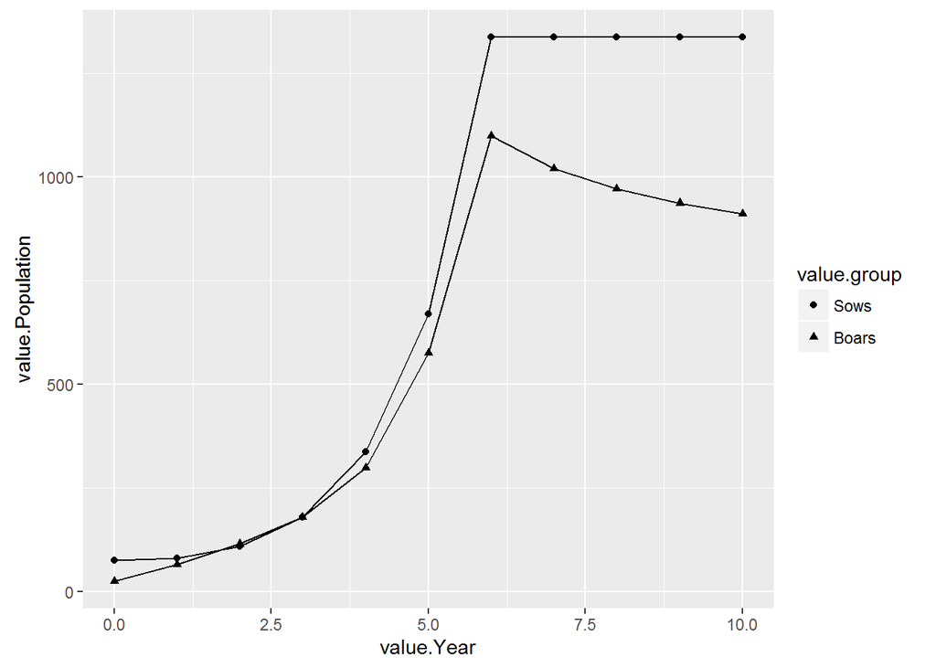

## 2.12 Counting Feral Swine and Presence

Most of the functions of this model rely on a perception of the number of feral swine on a patch and on the map. There are two primary kinds of counts in this model, count of head and count of presence. Count of head is counting the actual number of animals. We see that in the first part of the counting function sows and boars are counted on each patch, then added together for a total count.

```
to count_and_claim
  ;count sows
      ask patches [
      ifelse any? sows-here
      [set sowCount count sows-here]
      [set sowCount 0]
      ]
    set sowCountSum count sows
  ;count boars
    ask patches [
      ifelse any? boars-here
      [set boarCount count boars-here]
      [set boarCount 0]
      ]
    set boarCountSum count boars
  ;add them together
    set pigCountSum (boarCountSum + sowCountSum)
```

The next part establishes which sounder claims a given patch. The sounders simply claim patches that are in a radius of four patches. Sounders are presented each period in random order and the last sounder to claim a patch will have ownership of it. Movement of sounders is based on the outcome of `sounderTerritory`.

```
  ;establish sow territory
  if any? sounders[
     ask sounders [
       if any? sows with [sounder_id = [sounder_id] of myself]
       [
         let sid sounder_id
         ask patches in-radius 4 [; range of 5
           set sounderTerritory sid
         ]
       ]
     ]
  ]
```

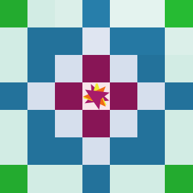

Example Feral Swine Presence

Applying this idea (with different colors) to the entire map in the figure below we see how presence compounds between animals across space.

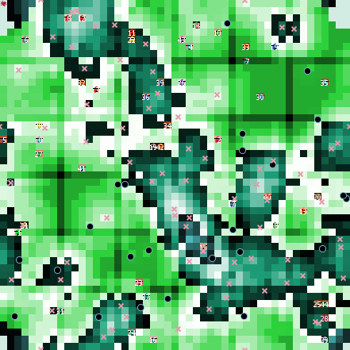

Example Feral Swine Presence - Entire Map

```
  ;establish the strength of sow territory
  ask patches [
    if any? sows [
      let sh count sows-here
      let s1 count sows in-radius 1
      let s2 count sows in-radius 2
      let s3 count sows in-radius 3
      let s4 count sows in-radius 4
      let s5 count sows in-radius 5
      set sts (sh +
        s1 - sh * (1 / 4) +
        s2 - s1 * (1 / 8) +
        s3 - s2 * (1 / 16) +
        s4 - s3 * (1 / 32) +
        s5 - s4 * (1 / 64))
      ]


    if any? boars [
      let bh count boars-here
      let b1 count boars in-radius 1
      let b2 count boars in-radius 2
      let b3 count boars in-radius 3
      let b4 count boars in-radius 4
      let b5 count boars in-radius 5
      set bts (bh +
        (b1 - bh) * (1 / 4) +
        (b2 - b1) * (1 / 8) +
        (b3 - b2) * (1 / 16) +
        (b4 - b3) * (1 / 32) +
        (b5 - b4) * (1 / 64))
    ]
      set pigTerritoryStrength (bts + sts + 2.22e-16)
      set pcolor pcolor + pigTerritoryStrength
      set boarTerritoryStrength bts
      set sounderTerritoryStrength sts
      set bts 0
      set sts 0
    ]
end
```

`pigTerritoryStrength`, `boarTerritoryStrength`, `sounderTerritoryStrength`, `boarCountSum`, and `sowCountSum` will be used for the major functions of the model.

## 2.13 Miscellaneous and Processing Functions

```r
#' @rdname WildPigABM
#' @export
clearNL <- function(verboseR,...){
  RNetLogo::NLCommand("clear-all")
  if (verboseR == TRUE){print("NL Cleared!")}
}
```

### 2.13.1 countDead() - Count killed feral swine

```r
# Count the Dead --------------
#' @rdname WildPigABM
#' @export
countDead <- function(verboseR,...){
  RNetLogo::NLCommand('countDead')
  c <- RNetLogo::NLReport("killed-count")
  if (verboseR == TRUE) {print("dead counted!")}
  return(c)
}
```

```
to countDead
  if any? killed[
  set killed-count ((count killed) + killed-count)
  ]
end
```

### 2.13.2 countHouseholds() - Count households in NL and report back to R

```r
#' @rdname WildPigABM
#' @examples \dontrun{countHouseholds()}
#' @export
countHouseholds <- function(){
  households <- RNetLogo::NLGetAgentSet("who", "households")
  return(households)
}
```

### 2.13.3 countOtherWildlife - Count the otherwildlife if turned on

```r
#' @rdname WildPigABM
#' @export
countOtherWildlife <- function(map_height, map_width,...) {
  if (competingWildlife == TRUE){
    RNetLogo::NLCommand(
      "ask patches [
    set othercrittercount count othercritters-here
    ]"
    )# count patches with pigs etc
    array(data = RNetLogo::NLGetPatches("othercrittercount",
                                        as.data.frame = FALSE, as.matrix = TRUE),
          c(map_height, map_width))
  }
}
```

### 2.13.4 generateAndPassPV() - Generate and pass patch variables to NL

```r
#' @rdname WildPigABM
#' @export
generateAndPassPV <- function(map_height,map_width,total_patches,
                              allow,
                              varCost_corn, varCost_soy, verCost_CRP,
                              P_corn, P_soy, P_CRP,
                              t_corn, t_soy, t_CRP,
                              Yield_soy, Yield_corn,
                              ...){
  initialPatchVarArray <- array(data=0,c(map_height, map_width,8))
  dimnames(initialPatchVarArray) <- list(paste("height",1:map_height,sep = ""),
                           paste("width",1:map_width,sep = ""),
                           c("quality","effect_comm","effect_free","effect_govt","effect_fee","memory","patch_id","psi_lastPeriod"))

  # generate quality variable for each patch
  initialPatchVarArray[,,'quality']       <- array(data = stats::runif(total_patches, min = 0.5, max = (1.5)),c(map_height, map_width))
  # generate effect_comm variable for each patch
  initialPatchVarArray[,,'effect_comm']   <- array(data = stats::runif(total_patches, min = 0.5, max = (1 + 2.220e-16)),c(map_height, map_width))
  # generate effect_free variable for each patch
  initialPatchVarArray[,,'effect_free']   <- array(data = stats::runif(total_patches, min = 0.5, max = (1 + 2.220e-16)),c(map_height, map_width))
  # generate effect_govt variable for each patch
  initialPatchVarArray[,,'effect_govt']   <- array(data = stats::runif(total_patches, min = 0.5, max = (1 + 2.220e-16)),c(map_height, map_width))
  # generate effect_fee variable for each patch
  initialPatchVarArray[,,'effect_fee']    <- array(data = stats::runif(total_patches, min = 0.9, max = (1 + 2.220e-16)),c(map_height, map_width))
  # generate memory variable for each patch
  initialPatchVarArray[,,'memory']        <- array(data = stats::runif(total_patches, min = -0.25, max = -.01),c(map_height, map_width))
  # generate patch_id variable for each patch
  initialPatchVarArray[,,'patch_id']       <- array(data = 1:(total_patches), c(map_height, map_width))
  # generate initial psi_t-1 variable for each patch
  initialPatchVarArray[,,'psi_lastPeriod'] <- array(data = 2.220e-16, c(map_height, map_width))


  NL_pushToMap("quality",initialPatchVarArray[,,'quality'],nl.obj = NULL)
  NL_pushToMap("effect_comm",initialPatchVarArray[,,'effect_comm'],nl.obj = NULL)
  NL_pushToMap("effect_free",initialPatchVarArray[,,'effect_free'],nl.obj = NULL)
  NL_pushToMap("effect_govt",initialPatchVarArray[,,'effect_govt'],nl.obj = NULL)
  NL_pushToMap("effect_fee",initialPatchVarArray[,,'effect_fee'],nl.obj = NULL)
  NL_pushToMap("memory",initialPatchVarArray[,,'memory'] ,nl.obj = NULL)
  NL_pushToMap("patch_id", initialPatchVarArray[,,'patch_id'],nl.obj = NULL)
  NL_pushToMap("psi_lastPeriod",initialPatchVarArray[,,'psi_lastPeriod'] ,nl.obj = NULL)

  #allow
  RNetLogo::NLSetPatches('allowFee',allow[,,'fee'])
  RNetLogo::NLSetPatches('allowFree',allow[,,"free"])
  RNetLogo::NLSetPatches('allowPro',allow[,,'pro'])
  #varcost
  vca <- array(data=0,c(map_height, map_width,6))
  dimnames(vca) <- list(paste("height",1:map_height,sep = ""),
                        paste("width",1:map_width,sep = ""),
                        c("Corn","Soy","CRP","SellPaid","Free","PayPaid"))
  vca[,,'Corn']     <- array(data = varCost_corn, c(map_height, map_width))
  vca[,,'Soy']      <- array(data = varCost_soy, c(map_height, map_width))
  vca[,,'CRP']      <- array(data = verCost_CRP, c(map_height, map_width))
  RNetLogo::NLSetPatches('varCost_corn',vca[,,'Corn'])
  RNetLogo::NLSetPatches('varCost_soy',vca[,,'Soy'] )
  RNetLogo::NLSetPatches('verCost_CRP',vca[,,'CRP'])
  # update Prices--------------------------------------------------------------------------
  prices <- array(data=0,c(map_height, map_width,6))
  dimnames(prices) <- list(paste("height",1:map_height,sep = ""),
                           paste("width",1:map_width,sep = ""),
                           c("pCorn","pSoy","pCRP","pSellPaid","pFree","pPayPaid"))
  prices[,,'pCorn']     <- array(data = P_corn, c(map_height, map_width))
  prices[,,'pSoy']      <- array(data = P_soy, c(map_height, map_width))
  prices[,,'pCRP']      <- array(data = P_CRP, c(map_height, map_width))
  RNetLogo::NLSetPatches('P_corn',prices[,,'pCorn'])
  RNetLogo::NLSetPatches('P_soy',prices[,,'pSoy'] )
  RNetLogo::NLSetPatches('P_CRP',prices[,,'pCRP'])
  # create yield matrices----------------------------------------------------------
  yield<-array(data=0,c(map_height, map_width,3))
  dimnames(yield) <- list(paste("height",1:map_height,sep = ""),
                          paste("width",1:map_width,sep = ""),
                          c("Yield_corn","Yield_soy","Yield_CRP"))
  yield[,,'Yield_corn']    <- matrix(data=Yield_corn,nrow=map_height,ncol=map_width)
  yield[,,'Yield_soy']    <- matrix(data=Yield_soy,nrow=map_height,ncol=map_width)
  yield[,,'Yield_CRP']    <- matrix(data=patchSize,nrow=map_height,ncol=map_width)
  RNetLogo::NLSetPatches('Yield_corn',yield[,,'Yield_corn'])
  RNetLogo::NLSetPatches('Yield_soy',yield[,,'Yield_soy'])
  RNetLogo::NLSetPatches('Yield_CRP',yield[,,'Yield_CRP'])
  # send time requirement to NL
  time <- array(0,c(map_height,map_width,6))
  dimnames(time) <- list(paste('height',1:map_height,sep = ""),
                         paste('width',1:map_width,sep = ""),
                         c('corn','soy','CRP','FEEPAYING',
                           'UNPAIDPRES','PAIDREMOVAL'))
  time[,,'corn'] <- array(data = t_corn, c(map_height,map_width))
  time[,,'soy'] <- array(data = t_soy, c(map_height,map_width))
  time[,,'CRP'] <- array(data = t_CRP, c(map_height,map_width))
  RNetLogo::NLSetPatches('t_soy',time[,,'soy'])
  RNetLogo::NLSetPatches('t_corn',time[,,'corn'])
  RNetLogo::NLSetPatches('t_CRP',time[,,'CRP'])



  return(initialPatchVarArray)
}
```

### 2.13.5 indivArraySpace() Create HH Result Space Arrays

```r
#' @rdname WildPigABM
#' @export
indivArraySpace <- function(data, max_cycles,...){
  array(data, c(1, max_cycles))
}
```

### 2.13.6 is.installed() detect packages

```r
#' @keywords wild pigs
#' @examples \dontrun{is.installed("cplexAPI")}
#' @rdname WildPigABM
#' @export
is.installed <- function(mypkg) is.element(mypkg, installed.packages()[,1])
```

### 2.13.7 mapArraySpace() Create Map Result Space Arrays

```r
#' @rdname WildPigABM
#' @export
mapArraySpace <- function(data,map_height,map_width,max_cycles,...){
  array(data, c(map_height, map_width, max_cycles))
}
```

### 2.13.8 NL_pushToMap() Push characteristic to map in NL

```r
#' @rdname WildPigABM
#' @export
NL_pushToMap <- function(NLcharacteristic,data,nl.obj = NULL, ...){
  RNetLogo::NLSetPatches(NLcharacteristic, data, nl.obj = NULL)
  if (verboseR == TRUE) {print("map data pushed to NL!")}
}
```

### 2.13.9 normalize() Normalize data to fall between 0 and 1

```r
#' @rdname WildPigABM
#' @export
normalize <- function(x){(x-min(x) + 2.220e-15)/(max(x)-min(x) + 2.220e-15)}
```

### 2.13.10 setIterName() - set a name for each iteration

```r
#' @rdname WildPigABM
#' @examples \dontrun{setIterName(t,now,verboseR=FALSE)}
#' @export
setIterName <- function(t, now, verboseR = FALSE, ...) {
  iterName <- paste("iteration_", t, "_", now, sep = "")
  if (verboseR == TRUE){print(iterName)}
  return(iterName)
}
```

## 2.14 GAMS Code For OCPM

```r
cat(readLines('Untitled_6.gms'), sep = '\n')
```

```
Sets
 n1 /p1/
 t period    /0*75/
 k crop     /corn,soy,crp/  ;

Parameters

  Yield(k)
  /corn  66150
  soy    22250
  crp 490/
  P(k)
  /corn  3.71
  soy    9.15
  crp 75/
  VC(k)
  /corn  183260
  soy    115640
  crp 2.22e-16/
  c(k)
  /corn  0.0237
  soy    0.171
  crp 2.22e-16/
Quality(n1)
 / p1        =        1
/
  ;
Scalars

 r       discount rate    1 2 5 real rate
  /.05/
  gamma  reproductive rate  (60% baseline) [0 1]
  /0.70/
 Premoval
/4/
 maxD      "max density of FS - based on zivin 15pigs/km2 this is approx 2km2"
  /30/
initPigs initial number of FS
/21/
   ;
```

[output cut: 123 more lines]

```
Total.iterlim = 4000;
Option NLP = COINIPOPT
Solve Total using NLP maximizing z;
execute_unload "Result2.gdx" CONTROL.M use.L use.M   rP.L rP.M  q.L q.M  z.L initPigs;
execute 'gdxxrw.exe Result2.gdx equ=CONTROL.M rng=CONTROL.M!A1'
execute 'gdxxrw.exe Result2.gdx var=rP.L rng=rP.L!A1'
execute 'gdxxrw.exe Result2.gdx var=q.L rng=q.L!A1'
execute 'gdxxrw.exe Result2.gdx var=z.L rng=z.L!A1';


*"  DmgPop(n1,t)$(ord(t) ne 1)   .. [rP(n1,t)+sum((n4),rP(n4,t)*0.5)] =e= dpop(n1,t)  ;"

*" varCost_{Paid} =     "
*"  Bal(n1,t)$(ord(t) ne 1)      .. =e= mov(n1,t) ;           "
*" [rP(n1,t-1)+[rP(n1,t-1)*gamma*{1-[rP(n1,t-1)*maxD**(-1)]}]] -rP(n4,t)*q(n4,t)) -rP(n1,t)*q(n1,t)  "
```

## 2.15 NetLogo Complete Script

```r
cat(readLines('~/GitHub/Version 2/WildPigABM/data/FromR_1.0.nlogo'),n = -1, sep = '\n')
```

```
breed [intersections intersection]
breed [killed one-killed]
breed [tk otk]
breed [households household]
breed [sounders sounder]
breed [boars boar]
breed [sows sow]
breed [pigs pig]
breed [otherCritters otherCritter]
breed [govt one-govt]

sounders-own [sounder_id
              age
              scount
]


households-own [
                HH_income  ;;
                hh_num  ;;
                wealthi  ;;
                ]

govt-own [policy]

boars-own [
               age  ;;
               bcagey  ;;
               mypsi ;;
               pig_num  ;;
               prRemoved
               ]
sows-own [
               age  ;;
               litter  ;;
               mypsi

               pig_num  ;;
               scagey  ;;
               sounder_id
```

[output cut: 2034 more lines]

[output not shown]

# References

Anderson, A., C. Slootmaker, E. Harper, J. Holderieath, and S.A. Shwiff. 2016. “Economic estimates of feral swine damage and control in 11 US states.” *Crop Protection* 89. doi:10.1016/j.cropro.2016.06.023.

Berck, P., and G. Helfand. 2011. *The Economics of the Environment*. Pearson Addison-Wesley.

Bieber, Claudia, and Thomas Ruf. 2005. “Population Dynamics in Wild Boar Sus Scrofa: Ecology, Elasticity of Growth Rate and Implications for the Management of Pulsed Resource Consumers.” *Journal of Applied Ecology* 42 (6). Wiley Online Library: 1203–13.

Bodenchuk, Michael J. 2014. “Method specific costs of feral swine removal in a large metapopulation.” p.c.

Carson, Rhys. 2013. “‘Boared’ to death: Rooting out the feral hog issue in Texas.” *Texas Tech Administrative Law Journal* Summer 2013 (c): 1–32.

Field, B.C. 2001. *Natural Resource Economics: An Introduction*. Waveland Press.

Geisser, Hannes, and Heinz-Ulrich Reyer. 2005. “The Influence of Food and Temperature on Population Density of Wild Boar Sus Scrofa in the Thurgau (Switzerland).” *Journal of Zoology* 267 (1). Wiley Online Library: 89–96.

Hainds, Mark J. 2011. *Year of the Pig*. Tuscaloosa, AL: The University of Alabama Press.

Hanson, Laura B, Michael S Mitchell, James B Grand, D Buck Jolley, Bill D Sparklin, and Stephen S Ditchkoff. 2009. “Effect of Experimental Manipulation on Survival and Recruitment of Feral Pigs.” *Wildlife Research* 36 (3). CSIRO: 185–91.

Hone, Jim. 1995. “Spatial and temporal aspects of vertebrate pest damage with emphasis on feral pigs.” *Journal of Applied Ecology* 32 (2): 311–19. doi:10.2307/2405098.

Moss, C.B. 2013. *Agricultural Finance*. Routledge Textbooks in Environmental and Agricultural Economics. Taylor & Francis.

Railsback, Steven F, and Volker Grimm. 2011. *Agent-based and individual-based modeling: a practical introduction*. Princeton university press.

Saunders, G, and H Bryant. 1988. “The evaluation of a feral pig eradication program during a simulated exotic disease outbreak.” *Australian Wildlife Research* 15 (1): 73–81. doi:10.1071/WR9880073.

Schlichting, Peter E., Sarah R. Fritts, John J. Mayer, Philip S. Gipson, and C. Brad Dabbert. 2016. “Determinants of variation in home range of wild pigs.” *Wildlife Society Bulletin* 40 (3): 487–93. doi:10.1002/wsb.662.

Shi, Wei, and Scott H Irwin. 2005. “Optimal Hedging with a Subjective View: An Empirical Bayesian Approach.” *American Journal of Agricultural Economics* 87 (4). Oxford University Press USA: 918–30.

Thijssen, Geert. 1996. “Farmers’ investment behavior: An empirical assessment of two specifications of expectations.” *American Journal of Agricultural Economics* 78 (1). Oxford University Press: 166–74.

Zivin, Joshua, Brent M Hueth, and David Zilberman. 2000. “Managing a Multiple-Use Resource: The Case of Feral Pig Management in California Rangeland.” *Journal of Environmental Economics and Management* 39 (2): 189–204. doi:http://dx.doi.org/10.1006/jeem.1999.1101.